# AUTHOR: BAZAROV MEHROL

# Program: Udacity Data Analyst Nanodegree Program

# Project: TMDb movie data

- Introduction
- Data Wrangling
- Exploratory Data Analysis
- Conclusions

#### In each table of contents, I gave different sections for each content.

# Introduction

Welcome to the captivating world of movies! In this project, we have explored a fascinating dataset, tmdb_movie.csv, which is a goldmine of information on thousands of movies. From the romance of the classics to the action-packed thrillers of today, we have analyzed and gained insights into the realm of cinema.

With the help of Python and Jupyter Notebook, we have navigated through the vastness of the dataset, analyzed its various components and used data visualization techniques to gain a better understanding of it. We have answered some of the most intriguing questions like:

### **Questions to answer**

- **Question 1:** What are the names of top films which has the highest vote count (highest budget, highest revenue, highest popularity score, highest vote_average)?
- **Question 2:** What are the shapes of the distribution? Which variables skewed to the left? Which skewed to right?
- **Question 3.1:** Is a movie more popular if it has a higher budget?
- **Question 3.2:** Is popularity depends on vote_average?
- **Question 3.3:** Are movies getting shorter?
- **Question 3.4:** To have more vote_counts lead to have high vote_average rating?
- **Question 3.5:** Is it true that movie with high vote_count tend to be popular?
- **Question 4.1:** Which movie is the most profitable and which is the opposite?
- **Question 4.2:** How many movies are profitable in this dataset?

Through this project, we have delved deep into the world of movies and explored how data can help us understand the trends, preferences and changing dynamics of the film industry.

So, buckle up and join us on this exciting journey into the world of movies!

### **Key takeaways**

- Import data into Python using `pandas` — Python’s most popular data analysis package.
- Filter, delete unnecessary columns, and analyse datasets using pandas.
- Using `numpy` package for indexing, calculating correlations.
- Present data visualizations using `matplotlib` and `seaborn` — Python’s most popular data visualization packages.

### **The Dataset**

TMDB Movies Dataset is named `tmdb-movies.csv`, which contains observations of 10k+ movies like title, budget, revenue, cast, director, tagline, keywords, genres, release date, runtime and so on. If you are interested in movies and want to learn interesting things about them, this dataset is a great resource to explore. There are 21 columns in this dataset.

- `id`: Unique identifier for each movie
- `imdb_id`: Unique identifier of each movie on IMDb
- `popularity`: Popularity score of the movie
- `budget`: Budget of the movie in dollars
- `revenue`: Revenue generated by the movie
- `original_title`: Original title of the movie
- `cast`: Name of the actors and actresses who acted in the movie
- `homepage`: Website of the movie.
- `director`: Name of the director who directed the movie
- `tagline`: Movie’s tagline if any.
- `keywords`: The keywords or tags related to the movie.
- `overview`: Brief description of the movie.
- `runtime`: Duration of the movie in minutes
- `genres`: The genres of the movie.
- `production_companies`: Production companies involved in making the movie
- `release_date`: Release date of the movie
- `vote_count`: Number of votes received by the movie
- `vote_average`: Average rating of the movie
- `release_year`: Release year of the movie
- `budget_adj`: Budget of the movie in terms of 2010 dollars, accounting for inflation
- `revenue_adj`: Revenue of the movie in terms of 2010 dollars, accounting for inflation

```python
#importing necessary packages
import pandas as pd
import numpy as np
import matplotlib.pyplot as plt
import seaborn as sns

%matplotlib inline
```

# Data Wrangling

### Data wrangling consists of three steps:

1. Gather - loading data into Pandas Dataframe reading csv files.

2. Assess - quick investigation, assessing and building intuitions.

3. Clean - removing or imputing missing values, correcting errors, dealing with outliers, and handling duplicates.

Here are the sections: you can go through the links below:

- General properties
- Data Cleaning

### General Properties

```python
#Load tmdb movie into dataframe
df = pd.read_csv('tmdb-movies.csv')
#display first five rows of data
df.head(5)
```

|  | id | imdb_id | popularity | budget | revenue | original_title | cast | homepage | director | tagline | ... | overview | runtime | genres | production_companies | release_date | vote_count | vote_average | release_year | budget_adj | revenue_adj |
| --- | --- | --- | --- | --- | --- | --- | --- | --- | --- | --- | --- | --- | --- | --- | --- | --- | --- | --- | --- | --- | --- |
| 0 | 135397 | tt0369610 | 32.985763 | 150000000 | 1513528810 | Jurassic World | Chris Pratt\|Bryce Dallas Howard\|Irrfan Khan\|Vi... | http://www.jurassicworld.com/ | Colin Trevorrow | The park is open. | ... | Twenty-two years after the events of Jurassic ... | 124 | Action\|Adventure\|Science Fiction\|Thriller | Universal Studios\|Amblin Entertainment\|Legenda... | 6/9/15 | 5562 | 6.5 | 2015 | 1.379999e+08 | 1.392446e+09 |
| 1 | 76341 | tt1392190 | 28.419936 | 150000000 | 378436354 | Mad Max: Fury Road | Tom Hardy\|Charlize Theron\|Hugh Keays-Byrne\|Nic... | http://www.madmaxmovie.com/ | George Miller | What a Lovely Day. | ... | An apocalyptic story set in the furthest reach... | 120 | Action\|Adventure\|Science Fiction\|Thriller | Village Roadshow Pictures\|Kennedy Miller Produ... | 5/13/15 | 6185 | 7.1 | 2015 | 1.379999e+08 | 3.481613e+08 |
| 2 | 262500 | tt2908446 | 13.112507 | 110000000 | 295238201 | Insurgent | Shailene Woodley\|Theo James\|Kate Winslet\|Ansel... | http://www.thedivergentseries.movie/#insurgent | Robert Schwentke | One Choice Can Destroy You | ... | Beatrice Prior must confront her inner demons ... | 119 | Adventure\|Science Fiction\|Thriller | Summit Entertainment\|Mandeville Films\|Red Wago... | 3/18/15 | 2480 | 6.3 | 2015 | 1.012000e+08 | 2.716190e+08 |
| 3 | 140607 | tt2488496 | 11.173104 | 200000000 | 2068178225 | Star Wars: The Force Awakens | Harrison Ford\|Mark Hamill\|Carrie Fisher\|Adam D... | http://www.starwars.com/films/star-wars-episod... | J.J. Abrams | Every generation has a story. | ... | Thirty years after defeating the Galactic Empi... | 136 | Action\|Adventure\|Science Fiction\|Fantasy | Lucasfilm\|Truenorth Productions\|Bad Robot | 12/15/15 | 5292 | 7.5 | 2015 | 1.839999e+08 | 1.902723e+09 |
| 4 | 168259 | tt2820852 | 9.335014 | 190000000 | 1506249360 | Furious 7 | Vin Diesel\|Paul Walker\|Jason Statham\|Michelle ... | http://www.furious7.com/ | James Wan | Vengeance Hits Home | ... | Deckard Shaw seeks revenge against Dominic Tor... | 137 | Action\|Crime\|Thriller | Universal Pictures\|Original Film\|Media Rights ... | 4/1/15 | 2947 | 7.3 | 2015 | 1.747999e+08 | 1.385749e+09 |

5 rows × 21 columns

```python
#capitalize the first letter of columns in the dataframe
df.columns = df.columns.str.capitalize()
df.head(5)
```

|  | Id | Imdb_id | Popularity | Budget | Revenue | Original_title | Cast | Homepage | Director | Tagline | ... | Overview | Runtime | Genres | Production_companies | Release_date | Vote_count | Vote_average | Release_year | Budget_adj | Revenue_adj |
| --- | --- | --- | --- | --- | --- | --- | --- | --- | --- | --- | --- | --- | --- | --- | --- | --- | --- | --- | --- | --- | --- |
| 0 | 135397 | tt0369610 | 32.985763 | 150000000 | 1513528810 | Jurassic World | Chris Pratt\|Bryce Dallas Howard\|Irrfan Khan\|Vi... | http://www.jurassicworld.com/ | Colin Trevorrow | The park is open. | ... | Twenty-two years after the events of Jurassic ... | 124 | Action\|Adventure\|Science Fiction\|Thriller | Universal Studios\|Amblin Entertainment\|Legenda... | 6/9/15 | 5562 | 6.5 | 2015 | 1.379999e+08 | 1.392446e+09 |
| 1 | 76341 | tt1392190 | 28.419936 | 150000000 | 378436354 | Mad Max: Fury Road | Tom Hardy\|Charlize Theron\|Hugh Keays-Byrne\|Nic... | http://www.madmaxmovie.com/ | George Miller | What a Lovely Day. | ... | An apocalyptic story set in the furthest reach... | 120 | Action\|Adventure\|Science Fiction\|Thriller | Village Roadshow Pictures\|Kennedy Miller Produ... | 5/13/15 | 6185 | 7.1 | 2015 | 1.379999e+08 | 3.481613e+08 |
| 2 | 262500 | tt2908446 | 13.112507 | 110000000 | 295238201 | Insurgent | Shailene Woodley\|Theo James\|Kate Winslet\|Ansel... | http://www.thedivergentseries.movie/#insurgent | Robert Schwentke | One Choice Can Destroy You | ... | Beatrice Prior must confront her inner demons ... | 119 | Adventure\|Science Fiction\|Thriller | Summit Entertainment\|Mandeville Films\|Red Wago... | 3/18/15 | 2480 | 6.3 | 2015 | 1.012000e+08 | 2.716190e+08 |
| 3 | 140607 | tt2488496 | 11.173104 | 200000000 | 2068178225 | Star Wars: The Force Awakens | Harrison Ford\|Mark Hamill\|Carrie Fisher\|Adam D... | http://www.starwars.com/films/star-wars-episod... | J.J. Abrams | Every generation has a story. | ... | Thirty years after defeating the Galactic Empi... | 136 | Action\|Adventure\|Science Fiction\|Fantasy | Lucasfilm\|Truenorth Productions\|Bad Robot | 12/15/15 | 5292 | 7.5 | 2015 | 1.839999e+08 | 1.902723e+09 |
| 4 | 168259 | tt2820852 | 9.335014 | 190000000 | 1506249360 | Furious 7 | Vin Diesel\|Paul Walker\|Jason Statham\|Michelle ... | http://www.furious7.com/ | James Wan | Vengeance Hits Home | ... | Deckard Shaw seeks revenge against Dominic Tor... | 137 | Action\|Crime\|Thriller | Universal Pictures\|Original Film\|Media Rights ... | 4/1/15 | 2947 | 7.3 | 2015 | 1.747999e+08 | 1.385749e+09 |

5 rows × 21 columns

It’s a good practice to capitalize the first letter of column names in a dataset. This makes it easier to read and understand the data

```python
#returns tuple of dimensions of the dataframe
df.shape
```

```
(10866, 21)
```

```python
#returns the datatypes of the columns
df.dtypes
```

```
Id                        int64
Imdb_id                  object
Popularity              float64
Budget                    int64
Revenue                   int64
Original_title           object
Cast                     object
Homepage                 object
Director                 object
Tagline                  object
Keywords                 object
Overview                 object
Runtime                   int64
Genres                   object
Production_companies     object
Release_date             object
Vote_count                int64
Vote_average            float64
Release_year              int64
Budget_adj              float64
Revenue_adj             float64
dtype: object
```

```python
#displays concise summary with non-null values and data types
df.info()
```

```
<class 'pandas.core.frame.DataFrame'>
RangeIndex: 10866 entries, 0 to 10865
Data columns (total 21 columns):
 #   Column                Non-Null Count  Dtype
---  ------                --------------  -----
 0   Id                    10866 non-null  int64
 1   Imdb_id               10856 non-null  object
 2   Popularity            10866 non-null  float64
 3   Budget                10866 non-null  int64
 4   Revenue               10866 non-null  int64
 5   Original_title        10866 non-null  object
 6   Cast                  10790 non-null  object
 7   Homepage              2936 non-null   object
 8   Director              10822 non-null  object
 9   Tagline               8042 non-null   object
 10  Keywords              9373 non-null   object
 11  Overview              10862 non-null  object
 12  Runtime               10866 non-null  int64
 13  Genres                10843 non-null  object
 14  Production_companies  9836 non-null   object
 15  Release_date          10866 non-null  object
 16  Vote_count            10866 non-null  int64
 17  Vote_average          10866 non-null  float64
 18  Release_year          10866 non-null  int64
 19  Budget_adj            10866 non-null  float64
 20  Revenue_adj           10866 non-null  float64
dtypes: float64(4), int64(6), object(11)
memory usage: 1.3+ MB
```

```python
#returns number of unique values in each column
df.nunique()
```

```
Id                      10865
Imdb_id                 10855
Popularity              10814
Budget                    557
Revenue                  4702
Original_title          10571
Cast                    10719
Homepage                 2896
Director                 5067
Tagline                  7997
Keywords                 8804
Overview                10847
Runtime                   247
Genres                   2039
Production_companies     7445
Release_date             5909
Vote_count               1289
Vote_average               72
Release_year               56
Budget_adj               2614
Revenue_adj              4840
dtype: int64
```

```python
#returns descriptive statistics for each column of data
df.describe()
```

|  | Id | Popularity | Budget | Revenue | Runtime | Vote_count | Vote_average | Release_year | Budget_adj | Revenue_adj |
| --- | --- | --- | --- | --- | --- | --- | --- | --- | --- | --- |
| count | 10866.000000 | 10866.000000 | 1.086600e+04 | 1.086600e+04 | 10866.000000 | 10866.000000 | 10866.000000 | 10866.000000 | 1.086600e+04 | 1.086600e+04 |
| mean | 66064.177434 | 0.646441 | 1.462570e+07 | 3.982332e+07 | 102.070863 | 217.389748 | 5.974922 | 2001.322658 | 1.755104e+07 | 5.136436e+07 |
| std | 92130.136561 | 1.000185 | 3.091321e+07 | 1.170035e+08 | 31.381405 | 575.619058 | 0.935142 | 12.812941 | 3.430616e+07 | 1.446325e+08 |
| min | 5.000000 | 0.000065 | 0.000000e+00 | 0.000000e+00 | 0.000000 | 10.000000 | 1.500000 | 1960.000000 | 0.000000e+00 | 0.000000e+00 |
| 25% | 10596.250000 | 0.207583 | 0.000000e+00 | 0.000000e+00 | 90.000000 | 17.000000 | 5.400000 | 1995.000000 | 0.000000e+00 | 0.000000e+00 |
| 50% | 20669.000000 | 0.383856 | 0.000000e+00 | 0.000000e+00 | 99.000000 | 38.000000 | 6.000000 | 2006.000000 | 0.000000e+00 | 0.000000e+00 |
| 75% | 75610.000000 | 0.713817 | 1.500000e+07 | 2.400000e+07 | 111.000000 | 145.750000 | 6.600000 | 2011.000000 | 2.085325e+07 | 3.369710e+07 |
| max | 417859.000000 | 32.985763 | 4.250000e+08 | 2.781506e+09 | 900.000000 | 9767.000000 | 9.200000 | 2015.000000 | 4.250000e+08 | 2.827124e+09 |

```python
# print the column labels in the dataframe
for i, v in enumerate(df.columns):
    print(i, v)
```

```
0 Id
1 Imdb_id
2 Popularity
3 Budget
4 Revenue
5 Original_title
6 Cast
7 Homepage
8 Director
9 Tagline
10 Keywords
11 Overview
12 Runtime
13 Genres
14 Production_companies
15 Release_date
16 Vote_count
17 Vote_average
18 Release_year
19 Budget_adj
20 Revenue_adj
```

```python
#first 5 rows
df.head(5)
```

|  | Id | Imdb_id | Popularity | Budget | Revenue | Original_title | Cast | Homepage | Director | Tagline | ... | Overview | Runtime | Genres | Production_companies | Release_date | Vote_count | Vote_average | Release_year | Budget_adj | Revenue_adj |
| --- | --- | --- | --- | --- | --- | --- | --- | --- | --- | --- | --- | --- | --- | --- | --- | --- | --- | --- | --- | --- | --- |
| 0 | 135397 | tt0369610 | 32.985763 | 150000000 | 1513528810 | Jurassic World | Chris Pratt\|Bryce Dallas Howard\|Irrfan Khan\|Vi... | http://www.jurassicworld.com/ | Colin Trevorrow | The park is open. | ... | Twenty-two years after the events of Jurassic ... | 124 | Action\|Adventure\|Science Fiction\|Thriller | Universal Studios\|Amblin Entertainment\|Legenda... | 6/9/15 | 5562 | 6.5 | 2015 | 1.379999e+08 | 1.392446e+09 |
| 1 | 76341 | tt1392190 | 28.419936 | 150000000 | 378436354 | Mad Max: Fury Road | Tom Hardy\|Charlize Theron\|Hugh Keays-Byrne\|Nic... | http://www.madmaxmovie.com/ | George Miller | What a Lovely Day. | ... | An apocalyptic story set in the furthest reach... | 120 | Action\|Adventure\|Science Fiction\|Thriller | Village Roadshow Pictures\|Kennedy Miller Produ... | 5/13/15 | 6185 | 7.1 | 2015 | 1.379999e+08 | 3.481613e+08 |
| 2 | 262500 | tt2908446 | 13.112507 | 110000000 | 295238201 | Insurgent | Shailene Woodley\|Theo James\|Kate Winslet\|Ansel... | http://www.thedivergentseries.movie/#insurgent | Robert Schwentke | One Choice Can Destroy You | ... | Beatrice Prior must confront her inner demons ... | 119 | Adventure\|Science Fiction\|Thriller | Summit Entertainment\|Mandeville Films\|Red Wago... | 3/18/15 | 2480 | 6.3 | 2015 | 1.012000e+08 | 2.716190e+08 |
| 3 | 140607 | tt2488496 | 11.173104 | 200000000 | 2068178225 | Star Wars: The Force Awakens | Harrison Ford\|Mark Hamill\|Carrie Fisher\|Adam D... | http://www.starwars.com/films/star-wars-episod... | J.J. Abrams | Every generation has a story. | ... | Thirty years after defeating the Galactic Empi... | 136 | Action\|Adventure\|Science Fiction\|Fantasy | Lucasfilm\|Truenorth Productions\|Bad Robot | 12/15/15 | 5292 | 7.5 | 2015 | 1.839999e+08 | 1.902723e+09 |
| 4 | 168259 | tt2820852 | 9.335014 | 190000000 | 1506249360 | Furious 7 | Vin Diesel\|Paul Walker\|Jason Statham\|Michelle ... | http://www.furious7.com/ | James Wan | Vengeance Hits Home | ... | Deckard Shaw seeks revenge against Dominic Tor... | 137 | Action\|Crime\|Thriller | Universal Pictures\|Original Film\|Media Rights ... | 4/1/15 | 2947 | 7.3 | 2015 | 1.747999e+08 | 1.385749e+09 |

5 rows × 21 columns

```python
#last 5 rows
df.tail(5)
```

|  | Id | Imdb_id | Popularity | Budget | Revenue | Original_title | Cast | Homepage | Director | Tagline | ... | Overview | Runtime | Genres | Production_companies | Release_date | Vote_count | Vote_average | Release_year | Budget_adj | Revenue_adj |
| --- | --- | --- | --- | --- | --- | --- | --- | --- | --- | --- | --- | --- | --- | --- | --- | --- | --- | --- | --- | --- | --- |
| 10861 | 21 | tt0060371 | 0.080598 | 0 | 0 | The Endless Summer | Michael Hynson\|Robert August\|Lord 'Tally Ho' B... | NaN | Bruce Brown | NaN | ... | The Endless Summer, by Bruce Brown, is one of ... | 95 | Documentary | Bruce Brown Films | 6/15/66 | 11 | 7.4 | 1966 | 0.000000 | 0.0 |
| 10862 | 20379 | tt0060472 | 0.065543 | 0 | 0 | Grand Prix | James Garner\|Eva Marie Saint\|Yves Montand\|Tosh... | NaN | John Frankenheimer | Cinerama sweeps YOU into a drama of speed and ... | ... | Grand Prix driver Pete Aron is fired by his te... | 176 | Action\|Adventure\|Drama | Cherokee Productions\|Joel Productions\|Douglas ... | 12/21/66 | 20 | 5.7 | 1966 | 0.000000 | 0.0 |
| 10863 | 39768 | tt0060161 | 0.065141 | 0 | 0 | Beregis Avtomobilya | Innokentiy Smoktunovskiy\|Oleg Efremov\|Georgi Z... | NaN | Eldar Ryazanov | NaN | ... | An insurance agent who moonlights as a carthie... | 94 | Mystery\|Comedy | Mosfilm | 1/1/66 | 11 | 6.5 | 1966 | 0.000000 | 0.0 |
| 10864 | 21449 | tt0061177 | 0.064317 | 0 | 0 | What's Up, Tiger Lily? | Tatsuya Mihashi\|Akiko Wakabayashi\|Mie Hama\|Joh... | NaN | Woody Allen | WOODY ALLEN STRIKES BACK! | ... | In comic Woody Allen's film debut, he took the... | 80 | Action\|Comedy | Benedict Pictures Corp. | 11/2/66 | 22 | 5.4 | 1966 | 0.000000 | 0.0 |
| 10865 | 22293 | tt0060666 | 0.035919 | 19000 | 0 | Manos: The Hands of Fate | Harold P. Warren\|Tom Neyman\|John Reynolds\|Dian... | NaN | Harold P. Warren | It's Shocking! It's Beyond Your Imagination! | ... | A family gets lost on the road and stumbles up... | 74 | Horror | Norm-Iris | 11/15/66 | 15 | 1.5 | 1966 | 127642.279154 | 0.0 |

5 rows × 21 columns

## Polishing Raw Data: The Art of Data Cleaning

### I handled this 6 steps in my data cleaning part.

- 1. Drop Duplicate rows
- 1. Appending new cell, changing index for comfotable use
- 1. Drop duplicate columns which is not necessary for analysis
- 1. Renaming columns to better use
- 1. Dropping null values
- 1. Inspecting and changing data types and filling Missing values with mean values of appropriate column

### 1. Drop duplicate rows

```python
# check for duplicates in the data
sum(df.duplicated())
```

```
1
```

```python
#print duplicated rows
duplicate = df[df.duplicated()]

print("Duplicate Rows :")

duplicate
```

```
Duplicate Rows :
```

|  | Id | Imdb_id | Popularity | Budget | Revenue | Original_title | Cast | Homepage | Director | Tagline | ... | Overview | Runtime | Genres | Production_companies | Release_date | Vote_count | Vote_average | Release_year | Budget_adj | Revenue_adj |
| --- | --- | --- | --- | --- | --- | --- | --- | --- | --- | --- | --- | --- | --- | --- | --- | --- | --- | --- | --- | --- | --- |
| 2090 | 42194 | tt0411951 | 0.59643 | 30000000 | 967000 | TEKKEN | Jon Foo\|Kelly Overton\|Cary-Hiroyuki Tagawa\|Ian... | NaN | Dwight H. Little | Survival is no game | ... | In the year of 2039, after World Wars destroy ... | 92 | Crime\|Drama\|Action\|Thriller\|Science Fiction | Namco\|Light Song Films | 3/20/10 | 110 | 5.0 | 2010 | 30000000.0 | 967000.0 |

1 rows × 21 columns

```python
#check the duplicated rows using df.query
duplicate = df.query('Id == 42194')
duplicate
```

|  | Id | Imdb_id | Popularity | Budget | Revenue | Original_title | Cast | Homepage | Director | Tagline | ... | Overview | Runtime | Genres | Production_companies | Release_date | Vote_count | Vote_average | Release_year | Budget_adj | Revenue_adj |
| --- | --- | --- | --- | --- | --- | --- | --- | --- | --- | --- | --- | --- | --- | --- | --- | --- | --- | --- | --- | --- | --- |
| 2089 | 42194 | tt0411951 | 0.59643 | 30000000 | 967000 | TEKKEN | Jon Foo\|Kelly Overton\|Cary-Hiroyuki Tagawa\|Ian... | NaN | Dwight H. Little | Survival is no game | ... | In the year of 2039, after World Wars destroy ... | 92 | Crime\|Drama\|Action\|Thriller\|Science Fiction | Namco\|Light Song Films | 3/20/10 | 110 | 5.0 | 2010 | 30000000.0 | 967000.0 |
| 2090 | 42194 | tt0411951 | 0.59643 | 30000000 | 967000 | TEKKEN | Jon Foo\|Kelly Overton\|Cary-Hiroyuki Tagawa\|Ian... | NaN | Dwight H. Little | Survival is no game | ... | In the year of 2039, after World Wars destroy ... | 92 | Crime\|Drama\|Action\|Thriller\|Science Fiction | Namco\|Light Song Films | 3/20/10 | 110 | 5.0 | 2010 | 30000000.0 | 967000.0 |

2 rows × 21 columns

```python
# drop duplicates
df.drop_duplicates(inplace=True)
```

```python
# confirm correction by rechecking for duplicates in the data
sum(df.duplicated())
```

```
0
```

### 2. Appending new cell - changing index

Later on I will drop unique identifiers which is named Id and Imdb_id column. Before that I am appending new cell named Num for making unique identifier for my entire dataset.

```python
#adding column to dataframe for seeing the place of the film in the dataframe
#making unique identifier for this dataset
df['Num'] = range(0, len(df))
df.head(5)
```

|  | Id | Imdb_id | Popularity | Budget | Revenue | Original_title | Cast | Homepage | Director | Tagline | ... | Runtime | Genres | Production_companies | Release_date | Vote_count | Vote_average | Release_year | Budget_adj | Revenue_adj | Num |
| --- | --- | --- | --- | --- | --- | --- | --- | --- | --- | --- | --- | --- | --- | --- | --- | --- | --- | --- | --- | --- | --- |
| 0 | 135397 | tt0369610 | 32.985763 | 150000000 | 1513528810 | Jurassic World | Chris Pratt\|Bryce Dallas Howard\|Irrfan Khan\|Vi... | http://www.jurassicworld.com/ | Colin Trevorrow | The park is open. | ... | 124 | Action\|Adventure\|Science Fiction\|Thriller | Universal Studios\|Amblin Entertainment\|Legenda... | 6/9/15 | 5562 | 6.5 | 2015 | 1.379999e+08 | 1.392446e+09 | 0 |
| 1 | 76341 | tt1392190 | 28.419936 | 150000000 | 378436354 | Mad Max: Fury Road | Tom Hardy\|Charlize Theron\|Hugh Keays-Byrne\|Nic... | http://www.madmaxmovie.com/ | George Miller | What a Lovely Day. | ... | 120 | Action\|Adventure\|Science Fiction\|Thriller | Village Roadshow Pictures\|Kennedy Miller Produ... | 5/13/15 | 6185 | 7.1 | 2015 | 1.379999e+08 | 3.481613e+08 | 1 |
| 2 | 262500 | tt2908446 | 13.112507 | 110000000 | 295238201 | Insurgent | Shailene Woodley\|Theo James\|Kate Winslet\|Ansel... | http://www.thedivergentseries.movie/#insurgent | Robert Schwentke | One Choice Can Destroy You | ... | 119 | Adventure\|Science Fiction\|Thriller | Summit Entertainment\|Mandeville Films\|Red Wago... | 3/18/15 | 2480 | 6.3 | 2015 | 1.012000e+08 | 2.716190e+08 | 2 |
| 3 | 140607 | tt2488496 | 11.173104 | 200000000 | 2068178225 | Star Wars: The Force Awakens | Harrison Ford\|Mark Hamill\|Carrie Fisher\|Adam D... | http://www.starwars.com/films/star-wars-episod... | J.J. Abrams | Every generation has a story. | ... | 136 | Action\|Adventure\|Science Fiction\|Fantasy | Lucasfilm\|Truenorth Productions\|Bad Robot | 12/15/15 | 5292 | 7.5 | 2015 | 1.839999e+08 | 1.902723e+09 | 3 |
| 4 | 168259 | tt2820852 | 9.335014 | 190000000 | 1506249360 | Furious 7 | Vin Diesel\|Paul Walker\|Jason Statham\|Michelle ... | http://www.furious7.com/ | James Wan | Vengeance Hits Home | ... | 137 | Action\|Crime\|Thriller | Universal Pictures\|Original Film\|Media Rights ... | 4/1/15 | 2947 | 7.3 | 2015 | 1.747999e+08 | 1.385749e+09 | 4 |

5 rows × 22 columns

```python
# shift column 'Num' to first position
first_column = df.pop('Num')

# insert column using insert(position,column_name,first_column) function
df.insert(0, 'Num', first_column)

df
```

|  | Num | Id | Imdb_id | Popularity | Budget | Revenue | Original_title | Cast | Homepage | Director | ... | Overview | Runtime | Genres | Production_companies | Release_date | Vote_count | Vote_average | Release_year | Budget_adj | Revenue_adj |
| --- | --- | --- | --- | --- | --- | --- | --- | --- | --- | --- | --- | --- | --- | --- | --- | --- | --- | --- | --- | --- | --- |
| 0 | 0 | 135397 | tt0369610 | 32.985763 | 150000000 | 1513528810 | Jurassic World | Chris Pratt\|Bryce Dallas Howard\|Irrfan Khan\|Vi... | http://www.jurassicworld.com/ | Colin Trevorrow | ... | Twenty-two years after the events of Jurassic ... | 124 | Action\|Adventure\|Science Fiction\|Thriller | Universal Studios\|Amblin Entertainment\|Legenda... | 6/9/15 | 5562 | 6.5 | 2015 | 1.379999e+08 | 1.392446e+09 |
| 1 | 1 | 76341 | tt1392190 | 28.419936 | 150000000 | 378436354 | Mad Max: Fury Road | Tom Hardy\|Charlize Theron\|Hugh Keays-Byrne\|Nic... | http://www.madmaxmovie.com/ | George Miller | ... | An apocalyptic story set in the furthest reach... | 120 | Action\|Adventure\|Science Fiction\|Thriller | Village Roadshow Pictures\|Kennedy Miller Produ... | 5/13/15 | 6185 | 7.1 | 2015 | 1.379999e+08 | 3.481613e+08 |
| 2 | 2 | 262500 | tt2908446 | 13.112507 | 110000000 | 295238201 | Insurgent | Shailene Woodley\|Theo James\|Kate Winslet\|Ansel... | http://www.thedivergentseries.movie/#insurgent | Robert Schwentke | ... | Beatrice Prior must confront her inner demons ... | 119 | Adventure\|Science Fiction\|Thriller | Summit Entertainment\|Mandeville Films\|Red Wago... | 3/18/15 | 2480 | 6.3 | 2015 | 1.012000e+08 | 2.716190e+08 |
| 3 | 3 | 140607 | tt2488496 | 11.173104 | 200000000 | 2068178225 | Star Wars: The Force Awakens | Harrison Ford\|Mark Hamill\|Carrie Fisher\|Adam D... | http://www.starwars.com/films/star-wars-episod... | J.J. Abrams | ... | Thirty years after defeating the Galactic Empi... | 136 | Action\|Adventure\|Science Fiction\|Fantasy | Lucasfilm\|Truenorth Productions\|Bad Robot | 12/15/15 | 5292 | 7.5 | 2015 | 1.839999e+08 | 1.902723e+09 |
| 4 | 4 | 168259 | tt2820852 | 9.335014 | 190000000 | 1506249360 | Furious 7 | Vin Diesel\|Paul Walker\|Jason Statham\|Michelle ... | http://www.furious7.com/ | James Wan | ... | Deckard Shaw seeks revenge against Dominic Tor... | 137 | Action\|Crime\|Thriller | Universal Pictures\|Original Film\|Media Rights ... | 4/1/15 | 2947 | 7.3 | 2015 | 1.747999e+08 | 1.385749e+09 |
| ... | ... | ... | ... | ... | ... | ... | ... | ... | ... | ... | ... | ... | ... | ... | ... | ... | ... | ... | ... | ... | ... |
| 10861 | 10860 | 21 | tt0060371 | 0.080598 | 0 | 0 | The Endless Summer | Michael Hynson\|Robert August\|Lord 'Tally Ho' B... | NaN | Bruce Brown | ... | The Endless Summer, by Bruce Brown, is one of ... | 95 | Documentary | Bruce Brown Films | 6/15/66 | 11 | 7.4 | 1966 | 0.000000e+00 | 0.000000e+00 |
| 10862 | 10861 | 20379 | tt0060472 | 0.065543 | 0 | 0 | Grand Prix | James Garner\|Eva Marie Saint\|Yves Montand\|Tosh... | NaN | John Frankenheimer | ... | Grand Prix driver Pete Aron is fired by his te... | 176 | Action\|Adventure\|Drama | Cherokee Productions\|Joel Productions\|Douglas ... | 12/21/66 | 20 | 5.7 | 1966 | 0.000000e+00 | 0.000000e+00 |
| 10863 | 10862 | 39768 | tt0060161 | 0.065141 | 0 | 0 | Beregis Avtomobilya | Innokentiy Smoktunovskiy\|Oleg Efremov\|Georgi Z... | NaN | Eldar Ryazanov | ... | An insurance agent who moonlights as a carthie... | 94 | Mystery\|Comedy | Mosfilm | 1/1/66 | 11 | 6.5 | 1966 | 0.000000e+00 | 0.000000e+00 |
| 10864 | 10863 | 21449 | tt0061177 | 0.064317 | 0 | 0 | What's Up, Tiger Lily? | Tatsuya Mihashi\|Akiko Wakabayashi\|Mie Hama\|Joh... | NaN | Woody Allen | ... | In comic Woody Allen's film debut, he took the... | 80 | Action\|Comedy | Benedict Pictures Corp. | 11/2/66 | 22 | 5.4 | 1966 | 0.000000e+00 | 0.000000e+00 |
| 10865 | 10864 | 22293 | tt0060666 | 0.035919 | 19000 | 0 | Manos: The Hands of Fate | Harold P. Warren\|Tom Neyman\|John Reynolds\|Dian... | NaN | Harold P. Warren | ... | A family gets lost on the road and stumbles up... | 74 | Horror | Norm-Iris | 11/15/66 | 15 | 1.5 | 1966 | 1.276423e+05 | 0.000000e+00 |

10865 rows × 22 columns

```python
#Selecting rows and identifying to choose the rows (recalling the choosing)
df.iloc[0:4]
```

|  | Num | Id | Imdb_id | Popularity | Budget | Revenue | Original_title | Cast | Homepage | Director | ... | Overview | Runtime | Genres | Production_companies | Release_date | Vote_count | Vote_average | Release_year | Budget_adj | Revenue_adj |
| --- | --- | --- | --- | --- | --- | --- | --- | --- | --- | --- | --- | --- | --- | --- | --- | --- | --- | --- | --- | --- | --- |
| 0 | 0 | 135397 | tt0369610 | 32.985763 | 150000000 | 1513528810 | Jurassic World | Chris Pratt\|Bryce Dallas Howard\|Irrfan Khan\|Vi... | http://www.jurassicworld.com/ | Colin Trevorrow | ... | Twenty-two years after the events of Jurassic ... | 124 | Action\|Adventure\|Science Fiction\|Thriller | Universal Studios\|Amblin Entertainment\|Legenda... | 6/9/15 | 5562 | 6.5 | 2015 | 1.379999e+08 | 1.392446e+09 |
| 1 | 1 | 76341 | tt1392190 | 28.419936 | 150000000 | 378436354 | Mad Max: Fury Road | Tom Hardy\|Charlize Theron\|Hugh Keays-Byrne\|Nic... | http://www.madmaxmovie.com/ | George Miller | ... | An apocalyptic story set in the furthest reach... | 120 | Action\|Adventure\|Science Fiction\|Thriller | Village Roadshow Pictures\|Kennedy Miller Produ... | 5/13/15 | 6185 | 7.1 | 2015 | 1.379999e+08 | 3.481613e+08 |
| 2 | 2 | 262500 | tt2908446 | 13.112507 | 110000000 | 295238201 | Insurgent | Shailene Woodley\|Theo James\|Kate Winslet\|Ansel... | http://www.thedivergentseries.movie/#insurgent | Robert Schwentke | ... | Beatrice Prior must confront her inner demons ... | 119 | Adventure\|Science Fiction\|Thriller | Summit Entertainment\|Mandeville Films\|Red Wago... | 3/18/15 | 2480 | 6.3 | 2015 | 1.012000e+08 | 2.716190e+08 |
| 3 | 3 | 140607 | tt2488496 | 11.173104 | 200000000 | 2068178225 | Star Wars: The Force Awakens | Harrison Ford\|Mark Hamill\|Carrie Fisher\|Adam D... | http://www.starwars.com/films/star-wars-episod... | J.J. Abrams | ... | Thirty years after defeating the Galactic Empi... | 136 | Action\|Adventure\|Science Fiction\|Fantasy | Lucasfilm\|Truenorth Productions\|Bad Robot | 12/15/15 | 5292 | 7.5 | 2015 | 1.839999e+08 | 1.902723e+09 |

4 rows × 22 columns

```python
#Setting index starting from 0 for matching with the Num column
#in order to not to confuse
df.index = np.arange(0, len(df))
df
```

|  | Num | Id | Imdb_id | Popularity | Budget | Revenue | Original_title | Cast | Homepage | Director | ... | Overview | Runtime | Genres | Production_companies | Release_date | Vote_count | Vote_average | Release_year | Budget_adj | Revenue_adj |
| --- | --- | --- | --- | --- | --- | --- | --- | --- | --- | --- | --- | --- | --- | --- | --- | --- | --- | --- | --- | --- | --- |
| 0 | 0 | 135397 | tt0369610 | 32.985763 | 150000000 | 1513528810 | Jurassic World | Chris Pratt\|Bryce Dallas Howard\|Irrfan Khan\|Vi... | http://www.jurassicworld.com/ | Colin Trevorrow | ... | Twenty-two years after the events of Jurassic ... | 124 | Action\|Adventure\|Science Fiction\|Thriller | Universal Studios\|Amblin Entertainment\|Legenda... | 6/9/15 | 5562 | 6.5 | 2015 | 1.379999e+08 | 1.392446e+09 |
| 1 | 1 | 76341 | tt1392190 | 28.419936 | 150000000 | 378436354 | Mad Max: Fury Road | Tom Hardy\|Charlize Theron\|Hugh Keays-Byrne\|Nic... | http://www.madmaxmovie.com/ | George Miller | ... | An apocalyptic story set in the furthest reach... | 120 | Action\|Adventure\|Science Fiction\|Thriller | Village Roadshow Pictures\|Kennedy Miller Produ... | 5/13/15 | 6185 | 7.1 | 2015 | 1.379999e+08 | 3.481613e+08 |
| 2 | 2 | 262500 | tt2908446 | 13.112507 | 110000000 | 295238201 | Insurgent | Shailene Woodley\|Theo James\|Kate Winslet\|Ansel... | http://www.thedivergentseries.movie/#insurgent | Robert Schwentke | ... | Beatrice Prior must confront her inner demons ... | 119 | Adventure\|Science Fiction\|Thriller | Summit Entertainment\|Mandeville Films\|Red Wago... | 3/18/15 | 2480 | 6.3 | 2015 | 1.012000e+08 | 2.716190e+08 |
| 3 | 3 | 140607 | tt2488496 | 11.173104 | 200000000 | 2068178225 | Star Wars: The Force Awakens | Harrison Ford\|Mark Hamill\|Carrie Fisher\|Adam D... | http://www.starwars.com/films/star-wars-episod... | J.J. Abrams | ... | Thirty years after defeating the Galactic Empi... | 136 | Action\|Adventure\|Science Fiction\|Fantasy | Lucasfilm\|Truenorth Productions\|Bad Robot | 12/15/15 | 5292 | 7.5 | 2015 | 1.839999e+08 | 1.902723e+09 |
| 4 | 4 | 168259 | tt2820852 | 9.335014 | 190000000 | 1506249360 | Furious 7 | Vin Diesel\|Paul Walker\|Jason Statham\|Michelle ... | http://www.furious7.com/ | James Wan | ... | Deckard Shaw seeks revenge against Dominic Tor... | 137 | Action\|Crime\|Thriller | Universal Pictures\|Original Film\|Media Rights ... | 4/1/15 | 2947 | 7.3 | 2015 | 1.747999e+08 | 1.385749e+09 |
| ... | ... | ... | ... | ... | ... | ... | ... | ... | ... | ... | ... | ... | ... | ... | ... | ... | ... | ... | ... | ... | ... |
| 10860 | 10860 | 21 | tt0060371 | 0.080598 | 0 | 0 | The Endless Summer | Michael Hynson\|Robert August\|Lord 'Tally Ho' B... | NaN | Bruce Brown | ... | The Endless Summer, by Bruce Brown, is one of ... | 95 | Documentary | Bruce Brown Films | 6/15/66 | 11 | 7.4 | 1966 | 0.000000e+00 | 0.000000e+00 |
| 10861 | 10861 | 20379 | tt0060472 | 0.065543 | 0 | 0 | Grand Prix | James Garner\|Eva Marie Saint\|Yves Montand\|Tosh... | NaN | John Frankenheimer | ... | Grand Prix driver Pete Aron is fired by his te... | 176 | Action\|Adventure\|Drama | Cherokee Productions\|Joel Productions\|Douglas ... | 12/21/66 | 20 | 5.7 | 1966 | 0.000000e+00 | 0.000000e+00 |
| 10862 | 10862 | 39768 | tt0060161 | 0.065141 | 0 | 0 | Beregis Avtomobilya | Innokentiy Smoktunovskiy\|Oleg Efremov\|Georgi Z... | NaN | Eldar Ryazanov | ... | An insurance agent who moonlights as a carthie... | 94 | Mystery\|Comedy | Mosfilm | 1/1/66 | 11 | 6.5 | 1966 | 0.000000e+00 | 0.000000e+00 |
| 10863 | 10863 | 21449 | tt0061177 | 0.064317 | 0 | 0 | What's Up, Tiger Lily? | Tatsuya Mihashi\|Akiko Wakabayashi\|Mie Hama\|Joh... | NaN | Woody Allen | ... | In comic Woody Allen's film debut, he took the... | 80 | Action\|Comedy | Benedict Pictures Corp. | 11/2/66 | 22 | 5.4 | 1966 | 0.000000e+00 | 0.000000e+00 |
| 10864 | 10864 | 22293 | tt0060666 | 0.035919 | 19000 | 0 | Manos: The Hands of Fate | Harold P. Warren\|Tom Neyman\|John Reynolds\|Dian... | NaN | Harold P. Warren | ... | A family gets lost on the road and stumbles up... | 74 | Horror | Norm-Iris | 11/15/66 | 15 | 1.5 | 1966 | 1.276423e+05 | 0.000000e+00 |

10865 rows × 22 columns

### 3. Drop duplicate columns

If you want to create a new dataframe with the modified data instead of modifying the original dataframe, you can simply omit the inplace=True parameter. For example:

```python
#create new dataframe for cleaned data
#9 columns We don't use during analysis
#drop
df_movie = df.drop(columns=['Id','Imdb_id', 'Budget', 'Revenue', 'Homepage', 'Tagline', 'Keywords', 'Overview', 'Release_date'], axis=1)
df_movie
```

|  | Num | Popularity | Original_title | Cast | Director | Runtime | Genres | Production_companies | Vote_count | Vote_average | Release_year | Budget_adj | Revenue_adj |
| --- | --- | --- | --- | --- | --- | --- | --- | --- | --- | --- | --- | --- | --- |
| 0 | 0 | 32.985763 | Jurassic World | Chris Pratt\|Bryce Dallas Howard\|Irrfan Khan\|Vi... | Colin Trevorrow | 124 | Action\|Adventure\|Science Fiction\|Thriller | Universal Studios\|Amblin Entertainment\|Legenda... | 5562 | 6.5 | 2015 | 1.379999e+08 | 1.392446e+09 |
| 1 | 1 | 28.419936 | Mad Max: Fury Road | Tom Hardy\|Charlize Theron\|Hugh Keays-Byrne\|Nic... | George Miller | 120 | Action\|Adventure\|Science Fiction\|Thriller | Village Roadshow Pictures\|Kennedy Miller Produ... | 6185 | 7.1 | 2015 | 1.379999e+08 | 3.481613e+08 |
| 2 | 2 | 13.112507 | Insurgent | Shailene Woodley\|Theo James\|Kate Winslet\|Ansel... | Robert Schwentke | 119 | Adventure\|Science Fiction\|Thriller | Summit Entertainment\|Mandeville Films\|Red Wago... | 2480 | 6.3 | 2015 | 1.012000e+08 | 2.716190e+08 |
| 3 | 3 | 11.173104 | Star Wars: The Force Awakens | Harrison Ford\|Mark Hamill\|Carrie Fisher\|Adam D... | J.J. Abrams | 136 | Action\|Adventure\|Science Fiction\|Fantasy | Lucasfilm\|Truenorth Productions\|Bad Robot | 5292 | 7.5 | 2015 | 1.839999e+08 | 1.902723e+09 |
| 4 | 4 | 9.335014 | Furious 7 | Vin Diesel\|Paul Walker\|Jason Statham\|Michelle ... | James Wan | 137 | Action\|Crime\|Thriller | Universal Pictures\|Original Film\|Media Rights ... | 2947 | 7.3 | 2015 | 1.747999e+08 | 1.385749e+09 |
| ... | ... | ... | ... | ... | ... | ... | ... | ... | ... | ... | ... | ... | ... |
| 10860 | 10860 | 0.080598 | The Endless Summer | Michael Hynson\|Robert August\|Lord 'Tally Ho' B... | Bruce Brown | 95 | Documentary | Bruce Brown Films | 11 | 7.4 | 1966 | 0.000000e+00 | 0.000000e+00 |
| 10861 | 10861 | 0.065543 | Grand Prix | James Garner\|Eva Marie Saint\|Yves Montand\|Tosh... | John Frankenheimer | 176 | Action\|Adventure\|Drama | Cherokee Productions\|Joel Productions\|Douglas ... | 20 | 5.7 | 1966 | 0.000000e+00 | 0.000000e+00 |
| 10862 | 10862 | 0.065141 | Beregis Avtomobilya | Innokentiy Smoktunovskiy\|Oleg Efremov\|Georgi Z... | Eldar Ryazanov | 94 | Mystery\|Comedy | Mosfilm | 11 | 6.5 | 1966 | 0.000000e+00 | 0.000000e+00 |
| 10863 | 10863 | 0.064317 | What's Up, Tiger Lily? | Tatsuya Mihashi\|Akiko Wakabayashi\|Mie Hama\|Joh... | Woody Allen | 80 | Action\|Comedy | Benedict Pictures Corp. | 22 | 5.4 | 1966 | 0.000000e+00 | 0.000000e+00 |
| 10864 | 10864 | 0.035919 | Manos: The Hands of Fate | Harold P. Warren\|Tom Neyman\|John Reynolds\|Dian... | Harold P. Warren | 74 | Horror | Norm-Iris | 15 | 1.5 | 1966 | 1.276423e+05 | 0.000000e+00 |

10865 rows × 13 columns

### NOTE

I see that It is uncomfortable for me to use columns which is capitalized, so it is better to lowercase them using lambda function.

```python
# replace spaces with underscores and lowercase labels for movie dataset
df_movie.rename(columns=lambda x: x.strip().lower().replace(" ", "_"), inplace=True)
df_movie
```

|  | num | popularity | original_title | cast | director | runtime | genres | production_companies | vote_count | vote_average | release_year | budget_adj | revenue_adj |
| --- | --- | --- | --- | --- | --- | --- | --- | --- | --- | --- | --- | --- | --- |
| 0 | 0 | 32.985763 | Jurassic World | Chris Pratt\|Bryce Dallas Howard\|Irrfan Khan\|Vi... | Colin Trevorrow | 124 | Action\|Adventure\|Science Fiction\|Thriller | Universal Studios\|Amblin Entertainment\|Legenda... | 5562 | 6.5 | 2015 | 1.379999e+08 | 1.392446e+09 |
| 1 | 1 | 28.419936 | Mad Max: Fury Road | Tom Hardy\|Charlize Theron\|Hugh Keays-Byrne\|Nic... | George Miller | 120 | Action\|Adventure\|Science Fiction\|Thriller | Village Roadshow Pictures\|Kennedy Miller Produ... | 6185 | 7.1 | 2015 | 1.379999e+08 | 3.481613e+08 |
| 2 | 2 | 13.112507 | Insurgent | Shailene Woodley\|Theo James\|Kate Winslet\|Ansel... | Robert Schwentke | 119 | Adventure\|Science Fiction\|Thriller | Summit Entertainment\|Mandeville Films\|Red Wago... | 2480 | 6.3 | 2015 | 1.012000e+08 | 2.716190e+08 |
| 3 | 3 | 11.173104 | Star Wars: The Force Awakens | Harrison Ford\|Mark Hamill\|Carrie Fisher\|Adam D... | J.J. Abrams | 136 | Action\|Adventure\|Science Fiction\|Fantasy | Lucasfilm\|Truenorth Productions\|Bad Robot | 5292 | 7.5 | 2015 | 1.839999e+08 | 1.902723e+09 |
| 4 | 4 | 9.335014 | Furious 7 | Vin Diesel\|Paul Walker\|Jason Statham\|Michelle ... | James Wan | 137 | Action\|Crime\|Thriller | Universal Pictures\|Original Film\|Media Rights ... | 2947 | 7.3 | 2015 | 1.747999e+08 | 1.385749e+09 |
| ... | ... | ... | ... | ... | ... | ... | ... | ... | ... | ... | ... | ... | ... |
| 10860 | 10860 | 0.080598 | The Endless Summer | Michael Hynson\|Robert August\|Lord 'Tally Ho' B... | Bruce Brown | 95 | Documentary | Bruce Brown Films | 11 | 7.4 | 1966 | 0.000000e+00 | 0.000000e+00 |
| 10861 | 10861 | 0.065543 | Grand Prix | James Garner\|Eva Marie Saint\|Yves Montand\|Tosh... | John Frankenheimer | 176 | Action\|Adventure\|Drama | Cherokee Productions\|Joel Productions\|Douglas ... | 20 | 5.7 | 1966 | 0.000000e+00 | 0.000000e+00 |
| 10862 | 10862 | 0.065141 | Beregis Avtomobilya | Innokentiy Smoktunovskiy\|Oleg Efremov\|Georgi Z... | Eldar Ryazanov | 94 | Mystery\|Comedy | Mosfilm | 11 | 6.5 | 1966 | 0.000000e+00 | 0.000000e+00 |
| 10863 | 10863 | 0.064317 | What's Up, Tiger Lily? | Tatsuya Mihashi\|Akiko Wakabayashi\|Mie Hama\|Joh... | Woody Allen | 80 | Action\|Comedy | Benedict Pictures Corp. | 22 | 5.4 | 1966 | 0.000000e+00 | 0.000000e+00 |
| 10864 | 10864 | 0.035919 | Manos: The Hands of Fate | Harold P. Warren\|Tom Neyman\|John Reynolds\|Dian... | Harold P. Warren | 74 | Horror | Norm-Iris | 15 | 1.5 | 1966 | 1.276423e+05 | 0.000000e+00 |

10865 rows × 13 columns

### 4. Renaming a column

I will change title for good use for my own usage

```python
#renaming a cloumn
df_movie.rename(columns={'original_title': 'title'}, inplace=True)
df_movie
```

|  | num | popularity | title | cast | director | runtime | genres | production_companies | vote_count | vote_average | release_year | budget_adj | revenue_adj |
| --- | --- | --- | --- | --- | --- | --- | --- | --- | --- | --- | --- | --- | --- |
| 0 | 0 | 32.985763 | Jurassic World | Chris Pratt\|Bryce Dallas Howard\|Irrfan Khan\|Vi... | Colin Trevorrow | 124 | Action\|Adventure\|Science Fiction\|Thriller | Universal Studios\|Amblin Entertainment\|Legenda... | 5562 | 6.5 | 2015 | 1.379999e+08 | 1.392446e+09 |
| 1 | 1 | 28.419936 | Mad Max: Fury Road | Tom Hardy\|Charlize Theron\|Hugh Keays-Byrne\|Nic... | George Miller | 120 | Action\|Adventure\|Science Fiction\|Thriller | Village Roadshow Pictures\|Kennedy Miller Produ... | 6185 | 7.1 | 2015 | 1.379999e+08 | 3.481613e+08 |
| 2 | 2 | 13.112507 | Insurgent | Shailene Woodley\|Theo James\|Kate Winslet\|Ansel... | Robert Schwentke | 119 | Adventure\|Science Fiction\|Thriller | Summit Entertainment\|Mandeville Films\|Red Wago... | 2480 | 6.3 | 2015 | 1.012000e+08 | 2.716190e+08 |
| 3 | 3 | 11.173104 | Star Wars: The Force Awakens | Harrison Ford\|Mark Hamill\|Carrie Fisher\|Adam D... | J.J. Abrams | 136 | Action\|Adventure\|Science Fiction\|Fantasy | Lucasfilm\|Truenorth Productions\|Bad Robot | 5292 | 7.5 | 2015 | 1.839999e+08 | 1.902723e+09 |
| 4 | 4 | 9.335014 | Furious 7 | Vin Diesel\|Paul Walker\|Jason Statham\|Michelle ... | James Wan | 137 | Action\|Crime\|Thriller | Universal Pictures\|Original Film\|Media Rights ... | 2947 | 7.3 | 2015 | 1.747999e+08 | 1.385749e+09 |
| ... | ... | ... | ... | ... | ... | ... | ... | ... | ... | ... | ... | ... | ... |
| 10860 | 10860 | 0.080598 | The Endless Summer | Michael Hynson\|Robert August\|Lord 'Tally Ho' B... | Bruce Brown | 95 | Documentary | Bruce Brown Films | 11 | 7.4 | 1966 | 0.000000e+00 | 0.000000e+00 |
| 10861 | 10861 | 0.065543 | Grand Prix | James Garner\|Eva Marie Saint\|Yves Montand\|Tosh... | John Frankenheimer | 176 | Action\|Adventure\|Drama | Cherokee Productions\|Joel Productions\|Douglas ... | 20 | 5.7 | 1966 | 0.000000e+00 | 0.000000e+00 |
| 10862 | 10862 | 0.065141 | Beregis Avtomobilya | Innokentiy Smoktunovskiy\|Oleg Efremov\|Georgi Z... | Eldar Ryazanov | 94 | Mystery\|Comedy | Mosfilm | 11 | 6.5 | 1966 | 0.000000e+00 | 0.000000e+00 |
| 10863 | 10863 | 0.064317 | What's Up, Tiger Lily? | Tatsuya Mihashi\|Akiko Wakabayashi\|Mie Hama\|Joh... | Woody Allen | 80 | Action\|Comedy | Benedict Pictures Corp. | 22 | 5.4 | 1966 | 0.000000e+00 | 0.000000e+00 |
| 10864 | 10864 | 0.035919 | Manos: The Hands of Fate | Harold P. Warren\|Tom Neyman\|John Reynolds\|Dian... | Harold P. Warren | 74 | Horror | Norm-Iris | 15 | 1.5 | 1966 | 1.276423e+05 | 0.000000e+00 |

10865 rows × 13 columns

### 5. Dropping null values

```python
# view missing value count for each feature in movie dataset
df_movie.isnull().sum()
```

```
num                        0
popularity                 0
title                      0
cast                      76
director                  44
runtime                    0
genres                    23
production_companies    1030
vote_count                 0
vote_average               0
release_year               0
budget_adj                 0
revenue_adj                0
dtype: int64
```

## NOTE LIMITATION1

If I drop movies, movies with good rating, or high budget_adj **MAYBE** omitted from this dataset. I am saying maybe not sure about that. So we may not always get accurate results. It will be tentative.

```python
# drop rows with any null values
df_movie.dropna(inplace=True)
```

```python
# checks if any of columns in movie dataset have null values - should print False
df_movie.isnull().sum().any()
```

```
False
```

```python
# print number of duplicates
print(df_movie.duplicated().sum())
```

```
0
```

```python
df_movie.shape
```

```
(9772, 13)
```

You can see small difference between original dataset vs df_movie cleaned dataset

```python
#returns descriptive statistics for each column of data
df.describe()
```

|  | Num | Id | Popularity | Budget | Revenue | Runtime | Vote_count | Vote_average | Release_year | Budget_adj | Revenue_adj |
| --- | --- | --- | --- | --- | --- | --- | --- | --- | --- | --- | --- |
| count | 10865.000000 | 10865.000000 | 10865.000000 | 1.086500e+04 | 1.086500e+04 | 10865.000000 | 10865.000000 | 10865.000000 | 10865.000000 | 1.086500e+04 | 1.086500e+04 |
| mean | 5432.000000 | 66066.374413 | 0.646446 | 1.462429e+07 | 3.982690e+07 | 102.071790 | 217.399632 | 5.975012 | 2001.321859 | 1.754989e+07 | 5.136900e+07 |
| std | 3136.599672 | 92134.091971 | 1.000231 | 3.091428e+07 | 1.170083e+08 | 31.382701 | 575.644627 | 0.935138 | 12.813260 | 3.430753e+07 | 1.446383e+08 |
| min | 0.000000 | 5.000000 | 0.000065 | 0.000000e+00 | 0.000000e+00 | 0.000000 | 10.000000 | 1.500000 | 1960.000000 | 0.000000e+00 | 0.000000e+00 |
| 25% | 2716.000000 | 10596.000000 | 0.207575 | 0.000000e+00 | 0.000000e+00 | 90.000000 | 17.000000 | 5.400000 | 1995.000000 | 0.000000e+00 | 0.000000e+00 |
| 50% | 5432.000000 | 20662.000000 | 0.383831 | 0.000000e+00 | 0.000000e+00 | 99.000000 | 38.000000 | 6.000000 | 2006.000000 | 0.000000e+00 | 0.000000e+00 |
| 75% | 8148.000000 | 75612.000000 | 0.713857 | 1.500000e+07 | 2.400000e+07 | 111.000000 | 146.000000 | 6.600000 | 2011.000000 | 2.085325e+07 | 3.370173e+07 |
| max | 10864.000000 | 417859.000000 | 32.985763 | 4.250000e+08 | 2.781506e+09 | 900.000000 | 9767.000000 | 9.200000 | 2015.000000 | 4.250000e+08 | 2.827124e+09 |

```python
#returns descriptive statistics for each column of data
df_movie.describe()
```

|  | num | popularity | runtime | vote_count | vote_average | release_year | budget_adj | revenue_adj |
| --- | --- | --- | --- | --- | --- | --- | --- | --- |
| count | 9772.000000 | 9772.000000 | 9772.000000 | 9772.000000 | 9772.000000 | 9772.000000 | 9.772000e+03 | 9.772000e+03 |
| mean | 5479.074499 | 0.694721 | 102.926627 | 239.312014 | 5.963528 | 2000.878428 | 1.941599e+07 | 5.705309e+07 |
| std | 3168.960772 | 1.036931 | 27.877432 | 603.011504 | 0.913174 | 13.036794 | 3.566634e+07 | 1.514499e+08 |
| min | 0.000000 | 0.000188 | 0.000000 | 10.000000 | 1.500000 | 1960.000000 | 0.000000e+00 | 0.000000e+00 |
| 25% | 2721.750000 | 0.232710 | 90.000000 | 18.000000 | 5.400000 | 1994.000000 | 0.000000e+00 | 0.000000e+00 |
| 50% | 5496.500000 | 0.419762 | 100.000000 | 46.000000 | 6.000000 | 2005.000000 | 3.061342e+05 | 0.000000e+00 |
| 75% | 8259.250000 | 0.776408 | 112.000000 | 173.000000 | 6.600000 | 2011.000000 | 2.464268e+07 | 4.311848e+07 |
| max | 10864.000000 | 32.985763 | 877.000000 | 9767.000000 | 8.700000 | 2015.000000 | 4.250000e+08 | 2.827124e+09 |

After dropping we should also change num and index values

```python
#Setting index starting from 0
df_movie.index = np.arange(0, len(df_movie))
df_movie
```

|  | num | popularity | title | cast | director | runtime | genres | production_companies | vote_count | vote_average | release_year | budget_adj | revenue_adj |
| --- | --- | --- | --- | --- | --- | --- | --- | --- | --- | --- | --- | --- | --- |
| 0 | 0 | 32.985763 | Jurassic World | Chris Pratt\|Bryce Dallas Howard\|Irrfan Khan\|Vi... | Colin Trevorrow | 124 | Action\|Adventure\|Science Fiction\|Thriller | Universal Studios\|Amblin Entertainment\|Legenda... | 5562 | 6.5 | 2015 | 1.379999e+08 | 1.392446e+09 |
| 1 | 1 | 28.419936 | Mad Max: Fury Road | Tom Hardy\|Charlize Theron\|Hugh Keays-Byrne\|Nic... | George Miller | 120 | Action\|Adventure\|Science Fiction\|Thriller | Village Roadshow Pictures\|Kennedy Miller Produ... | 6185 | 7.1 | 2015 | 1.379999e+08 | 3.481613e+08 |
| 2 | 2 | 13.112507 | Insurgent | Shailene Woodley\|Theo James\|Kate Winslet\|Ansel... | Robert Schwentke | 119 | Adventure\|Science Fiction\|Thriller | Summit Entertainment\|Mandeville Films\|Red Wago... | 2480 | 6.3 | 2015 | 1.012000e+08 | 2.716190e+08 |
| 3 | 3 | 11.173104 | Star Wars: The Force Awakens | Harrison Ford\|Mark Hamill\|Carrie Fisher\|Adam D... | J.J. Abrams | 136 | Action\|Adventure\|Science Fiction\|Fantasy | Lucasfilm\|Truenorth Productions\|Bad Robot | 5292 | 7.5 | 2015 | 1.839999e+08 | 1.902723e+09 |
| 4 | 4 | 9.335014 | Furious 7 | Vin Diesel\|Paul Walker\|Jason Statham\|Michelle ... | James Wan | 137 | Action\|Crime\|Thriller | Universal Pictures\|Original Film\|Media Rights ... | 2947 | 7.3 | 2015 | 1.747999e+08 | 1.385749e+09 |
| ... | ... | ... | ... | ... | ... | ... | ... | ... | ... | ... | ... | ... | ... |
| 9767 | 10860 | 0.080598 | The Endless Summer | Michael Hynson\|Robert August\|Lord 'Tally Ho' B... | Bruce Brown | 95 | Documentary | Bruce Brown Films | 11 | 7.4 | 1966 | 0.000000e+00 | 0.000000e+00 |
| 9768 | 10861 | 0.065543 | Grand Prix | James Garner\|Eva Marie Saint\|Yves Montand\|Tosh... | John Frankenheimer | 176 | Action\|Adventure\|Drama | Cherokee Productions\|Joel Productions\|Douglas ... | 20 | 5.7 | 1966 | 0.000000e+00 | 0.000000e+00 |
| 9769 | 10862 | 0.065141 | Beregis Avtomobilya | Innokentiy Smoktunovskiy\|Oleg Efremov\|Georgi Z... | Eldar Ryazanov | 94 | Mystery\|Comedy | Mosfilm | 11 | 6.5 | 1966 | 0.000000e+00 | 0.000000e+00 |
| 9770 | 10863 | 0.064317 | What's Up, Tiger Lily? | Tatsuya Mihashi\|Akiko Wakabayashi\|Mie Hama\|Joh... | Woody Allen | 80 | Action\|Comedy | Benedict Pictures Corp. | 22 | 5.4 | 1966 | 0.000000e+00 | 0.000000e+00 |
| 9771 | 10864 | 0.035919 | Manos: The Hands of Fate | Harold P. Warren\|Tom Neyman\|John Reynolds\|Dian... | Harold P. Warren | 74 | Horror | Norm-Iris | 15 | 1.5 | 1966 | 1.276423e+05 | 0.000000e+00 |

9772 rows × 13 columns

I will change also num because we need to change our unique identifier also.

```python
#change the value of unique identifier
df_movie['num'] = range(0, len(df_movie))
df_movie
```

|  | num | popularity | title | cast | director | runtime | genres | production_companies | vote_count | vote_average | release_year | budget_adj | revenue_adj |
| --- | --- | --- | --- | --- | --- | --- | --- | --- | --- | --- | --- | --- | --- |
| 0 | 0 | 32.985763 | Jurassic World | Chris Pratt\|Bryce Dallas Howard\|Irrfan Khan\|Vi... | Colin Trevorrow | 124 | Action\|Adventure\|Science Fiction\|Thriller | Universal Studios\|Amblin Entertainment\|Legenda... | 5562 | 6.5 | 2015 | 1.379999e+08 | 1.392446e+09 |
| 1 | 1 | 28.419936 | Mad Max: Fury Road | Tom Hardy\|Charlize Theron\|Hugh Keays-Byrne\|Nic... | George Miller | 120 | Action\|Adventure\|Science Fiction\|Thriller | Village Roadshow Pictures\|Kennedy Miller Produ... | 6185 | 7.1 | 2015 | 1.379999e+08 | 3.481613e+08 |
| 2 | 2 | 13.112507 | Insurgent | Shailene Woodley\|Theo James\|Kate Winslet\|Ansel... | Robert Schwentke | 119 | Adventure\|Science Fiction\|Thriller | Summit Entertainment\|Mandeville Films\|Red Wago... | 2480 | 6.3 | 2015 | 1.012000e+08 | 2.716190e+08 |
| 3 | 3 | 11.173104 | Star Wars: The Force Awakens | Harrison Ford\|Mark Hamill\|Carrie Fisher\|Adam D... | J.J. Abrams | 136 | Action\|Adventure\|Science Fiction\|Fantasy | Lucasfilm\|Truenorth Productions\|Bad Robot | 5292 | 7.5 | 2015 | 1.839999e+08 | 1.902723e+09 |
| 4 | 4 | 9.335014 | Furious 7 | Vin Diesel\|Paul Walker\|Jason Statham\|Michelle ... | James Wan | 137 | Action\|Crime\|Thriller | Universal Pictures\|Original Film\|Media Rights ... | 2947 | 7.3 | 2015 | 1.747999e+08 | 1.385749e+09 |
| ... | ... | ... | ... | ... | ... | ... | ... | ... | ... | ... | ... | ... | ... |
| 9767 | 9767 | 0.080598 | The Endless Summer | Michael Hynson\|Robert August\|Lord 'Tally Ho' B... | Bruce Brown | 95 | Documentary | Bruce Brown Films | 11 | 7.4 | 1966 | 0.000000e+00 | 0.000000e+00 |
| 9768 | 9768 | 0.065543 | Grand Prix | James Garner\|Eva Marie Saint\|Yves Montand\|Tosh... | John Frankenheimer | 176 | Action\|Adventure\|Drama | Cherokee Productions\|Joel Productions\|Douglas ... | 20 | 5.7 | 1966 | 0.000000e+00 | 0.000000e+00 |
| 9769 | 9769 | 0.065141 | Beregis Avtomobilya | Innokentiy Smoktunovskiy\|Oleg Efremov\|Georgi Z... | Eldar Ryazanov | 94 | Mystery\|Comedy | Mosfilm | 11 | 6.5 | 1966 | 0.000000e+00 | 0.000000e+00 |
| 9770 | 9770 | 0.064317 | What's Up, Tiger Lily? | Tatsuya Mihashi\|Akiko Wakabayashi\|Mie Hama\|Joh... | Woody Allen | 80 | Action\|Comedy | Benedict Pictures Corp. | 22 | 5.4 | 1966 | 0.000000e+00 | 0.000000e+00 |
| 9771 | 9771 | 0.035919 | Manos: The Hands of Fate | Harold P. Warren\|Tom Neyman\|John Reynolds\|Dian... | Harold P. Warren | 74 | Horror | Norm-Iris | 15 | 1.5 | 1966 | 1.276423e+05 | 0.000000e+00 |

9772 rows × 13 columns

### 6. Inspecting data types, changing data types and filling missing values with mean values

```python
#view of  data types
df_movie.dtypes
```

```
num                       int64
popularity              float64
title                    object
cast                     object
director                 object
runtime                   int64
genres                   object
production_companies     object
vote_count                int64
vote_average            float64
release_year              int64
budget_adj              float64
revenue_adj             float64
dtype: object
```

### NOTE LIMITATION 2

I dropped budget and revenue and keeping the other two columns budget_adj and revenue_adj.

I want to use budget_adj and revenue_adj columns as they account for inflation to compare budgets and revenues accross different years. It is my choice.

This two cells have scientific notation (e) values so I will change it to integer decimal value.

As you can see we have numerical values in Popularity, runtime, vote_count, vote_average, budget_adj and revenue_adj

```python
#let's check their unqique values
df_movie.popularity.unique()
```

```
array([32.985763, 28.419936, 13.112507, ...,  0.065141,  0.064317,
        0.035919])
```

```python
#Checking unique values for runtime
df_movie.runtime.unique()
# you can see we have zero
```

```
array([124, 120, 119, 136, 137, 156, 125, 141,  91,  94, 148, 108, 105,
       167, 109, 115, 112, 130, 123, 114, 131, 128, 132, 103, 117, 101,
        93, 111, 147, 106, 122, 116,  97,  92, 118, 121, 100, 133,  96,
       102,  95,  88,  99,  89, 107,   0,   8, 104,  98, 113,  85,  90,
        84,  82,  87,  31,  83,  48,  67,  86,  74, 134,   7, 110,  72,
        80, 127,  76,   5,  56, 135,  44,  75,  81,   4, 129,  78, 138,
        62,  43,  77, 153,  70,  73,  14,  57,  79, 168,  60,  54,  52,
        16,  65,  18,  64, 240,  17, 169, 144, 145, 139, 165, 142, 164,
        22,   6, 150, 233,  41, 210,  71,  23,   3, 152, 163, 285,  66,
       175, 155, 177, 143, 162, 158, 140,  30, 161, 170,  38, 146, 149,
        36,  27,  61,  26, 176,  69,  59, 500, 166, 185,  25,  58,  21,
       338, 182, 421,  15, 540, 184,  12, 178,  11, 189, 157, 159, 126,
       188, 181, 160,  33, 180, 183, 705, 400, 191, 213, 179, 470, 173,
        45,  10,  63, 154, 202, 201,  40, 192,  42, 247, 336,  68, 877,
        47, 254, 235, 366, 171, 273, 172,  24, 389,  19, 214, 352,   9,
       248,  49, 194, 186, 199, 566, 187, 223, 151, 270,  34, 219,  28,
       229,  29, 193, 197, 300, 225, 195, 242, 292, 372, 236, 200,  51,
       216, 208, 174], dtype=int64)
```

```python
#Checking unique values for vote_count
df_movie.vote_count.unique()
```

```
array([5562, 6185, 2480, ...,  641, 1113,  786], dtype=int64)
```

```python
df_movie.vote_average.unique()
```

```
array([6.5, 7.1, 6.3, 7.5, 7.3, 7.2, 5.8, 7.6, 8. , 6.2, 5.2, 7.4, 6.1,
       7. , 6.8, 5.3, 7.8, 6.4, 6.6, 7.7, 5.6, 6.9, 5.9, 6.7, 5.5, 5. ,
       4.4, 5.4, 5.1, 4.8, 5.7, 4.1, 3.9, 4.5, 6. , 4.2, 3.6, 4.3, 4.9,
       4.7, 4. , 3.5, 3.8, 3.3, 3.7, 4.6, 7.9, 3.1, 3.2, 2.4, 8.4, 8.2,
       3. , 2.8, 3.4, 8.1, 8.3, 2.7, 2.5, 2.9, 8.5, 2.1, 2.2, 2. , 2.6,
       8.7, 2.3, 1.5])
```

```python
#Checking unique values
df_movie.budget_adj.unique()
```

```
array([1.37999939e+08, 1.01199955e+08, 1.83999919e+08, ...,
       3.43626452e+07, 4.70261028e+06, 1.27642279e+05])
```

```python
# Select multiple columns
cols = ['popularity', 'vote_count', 'vote_average', 'budget_adj', 'revenue_adj', 'runtime']

# Check if some values are equal to zero and count them
for col in cols:
    zero_count = (df_movie[col] == 0).sum()
    print(f"{col} contains {zero_count} zero values.")
```

```
popularity contains 0 zero values.
vote_count contains 0 zero values.
vote_average contains 0 zero values.
budget_adj contains 4751 zero values.
revenue_adj contains 5022 zero values.
runtime contains 13 zero values.
```

### NOTE LIMITATION 3

After changing this, our exploration also will be changed. I also take it into consideration.

```python
# Calculate the mean value of the column
mean1 = df_movie['runtime'].mean()
mean2 = df_movie['budget_adj'].mean()
mean3 = df_movie['revenue_adj'].mean()

# Replace all the zero values with the mean value
df_movie['runtime'] = df_movie['runtime'].replace(0, mean1)
df_movie['budget_adj'] = df_movie['budget_adj'].replace(0, mean1)
df_movie['revenue_adj'] = df_movie['revenue_adj'].replace(0, mean1)
```

### NOTE

We don't have null values right now! It is cheking zero values again.

```python
# Select multiple columns which contains numerical values
cols = ['popularity', 'vote_count', 'vote_average', 'budget_adj', 'revenue_adj', 'runtime']

# Check if some values are equal to zero and count them
for col in cols:
    zero_count = (df_movie[col] == 0).sum()
    print(f"{col} contains {zero_count} zero values.")
```

```
popularity contains 0 zero values.
vote_count contains 0 zero values.
vote_average contains 0 zero values.
budget_adj contains 0 zero values.
revenue_adj contains 0 zero values.
runtime contains 0 zero values.
```

```python
#returns descriptive statistics for each column of data
df_movie.describe()
```

|  | num | popularity | runtime | vote_count | vote_average | release_year | budget_adj | revenue_adj |
| --- | --- | --- | --- | --- | --- | --- | --- | --- |
| count | 9772.000000 | 9772.000000 | 9772.000000 | 9772.000000 | 9772.000000 | 9772.000000 | 9.772000e+03 | 9.772000e+03 |
| mean | 4885.500000 | 0.694721 | 103.063554 | 239.312014 | 5.963528 | 2000.878428 | 1.941604e+07 | 5.705315e+07 |
| std | 2821.077749 | 1.036931 | 27.623136 | 603.011504 | 0.913174 | 13.036794 | 3.566631e+07 | 1.514499e+08 |
| min | 0.000000 | 0.000188 | 3.000000 | 10.000000 | 1.500000 | 1960.000000 | 9.210911e-01 | 2.370705e+00 |
| 25% | 2442.750000 | 0.232710 | 91.000000 | 18.000000 | 5.400000 | 1994.000000 | 1.029266e+02 | 1.029266e+02 |
| 50% | 4885.500000 | 0.419762 | 100.000000 | 46.000000 | 6.000000 | 2005.000000 | 3.061342e+05 | 1.029266e+02 |
| 75% | 7328.250000 | 0.776408 | 112.000000 | 173.000000 | 6.600000 | 2011.000000 | 2.464268e+07 | 4.311848e+07 |
| max | 9771.000000 | 32.985763 | 877.000000 | 9767.000000 | 8.700000 | 2015.000000 | 4.250000e+08 | 2.827124e+09 |

```python
#displays concise summary with non-null values and data types
df_movie.info()
```

```
<class 'pandas.core.frame.DataFrame'>
Int64Index: 9772 entries, 0 to 9771
Data columns (total 13 columns):
 #   Column                Non-Null Count  Dtype
---  ------                --------------  -----
 0   num                   9772 non-null   int64
 1   popularity            9772 non-null   float64
 2   title                 9772 non-null   object
 3   cast                  9772 non-null   object
 4   director              9772 non-null   object
 5   runtime               9772 non-null   float64
 6   genres                9772 non-null   object
 7   production_companies  9772 non-null   object
 8   vote_count            9772 non-null   int64
 9   vote_average          9772 non-null   float64
 10  release_year          9772 non-null   int64
 11  budget_adj            9772 non-null   float64
 12  revenue_adj           9772 non-null   float64
dtypes: float64(5), int64(3), object(5)
memory usage: 878.0+ KB
```

### 6.1 Now it is time to change the data types for runtime

### and also changing data types for budget_adj and revenue_adj

```python
# Change the data types of a column
df_movie['runtime'] = df_movie['runtime'].astype('int64')

# Print the data types of the columns to confirm the change
print(df_movie.dtypes)
```

```
num                       int64
popularity              float64
title                    object
cast                     object
director                 object
runtime                   int64
genres                   object
production_companies     object
vote_count                int64
vote_average            float64
release_year              int64
budget_adj              float64
revenue_adj             float64
dtype: object
```

```python
# Define a lambda function to change the format of the values in the column
format_func = lambda x: '{:.2f}'.format(x)

# Apply the lambda function to the column
df_movie['budget_adj'] = df_movie['budget_adj'].apply(format_func)

# Print the modified column to confirm the change
print(df_movie['budget_adj'])
```

```
0       137999939.28
1       137999939.28
2       101199955.47
3       183999919.04
4       174799923.09
            ...
9767          102.93
9768          102.93
9769          102.93
9770          102.93
9771       127642.28
Name: budget_adj, Length: 9772, dtype: object
```

```python
# Apply the lambda function to the revenue_adj
df_movie['revenue_adj'] = df_movie['revenue_adj'].apply(format_func)

# Print the modified column to confirm the change
print(df_movie['revenue_adj'])
```

```
0       1392445892.52
1        348161292.49
2        271619025.41
3       1902723129.80
4       1385748801.47
            ...
9767           102.93
9768           102.93
9769           102.93
9770           102.93
9771           102.93
Name: revenue_adj, Length: 9772, dtype: object
```

```python
# Print the data types of the columns
df_movie.dtypes
```

```
num                       int64
popularity              float64
title                    object
cast                     object
director                 object
runtime                   int64
genres                   object
production_companies     object
vote_count                int64
vote_average            float64
release_year              int64
budget_adj               object
revenue_adj              object
dtype: object
```

```python
#checking the value of a column
df_movie['budget_adj']
```

```
0       137999939.28
1       137999939.28
2       101199955.47
3       183999919.04
4       174799923.09
            ...
9767          102.93
9768          102.93
9769          102.93
9770          102.93
9771       127642.28
Name: budget_adj, Length: 9772, dtype: object
```

```python
# Convert the string values to float datatype
df_movie['budget_adj'] = df_movie['budget_adj'].astype(float)
df_movie['revenue_adj'] = df_movie['revenue_adj'].astype(float)

# Convert the float values to integer datatype
df_movie['budget_adj'] = df_movie['budget_adj'].astype(int)
df_movie['revenue_adj'] = df_movie['revenue_adj'].astype(int)

# Print the modified columns to confirm the change
print(df_movie['budget_adj'])
print(df_movie['revenue_adj'])
```

```
0       137999939
1       137999939
2       101199955
3       183999919
4       174799923
          ...
9767          102
9768          102
9769          102
9770          102
9771       127642
Name: budget_adj, Length: 9772, dtype: int32
0       1392445892
1        348161292
2        271619025
3       1902723129
4       1385748801
           ...
9767           102
9768           102
9769           102
9770           102
9771           102
Name: revenue_adj, Length: 9772, dtype: int32
```

```python
#returns descriptive statistics for each column of data after changing the types of 2 columns above
df_movie.describe()
```

|  | num | popularity | runtime | vote_count | vote_average | release_year | budget_adj | revenue_adj |
| --- | --- | --- | --- | --- | --- | --- | --- | --- |
| count | 9772.000000 | 9772.000000 | 9772.000000 | 9772.000000 | 9772.000000 | 9772.000000 | 9.772000e+03 | 9.772000e+03 |
| mean | 4885.500000 | 0.694721 | 103.062321 | 239.312014 | 5.963528 | 2000.878428 | 1.941604e+07 | 5.512104e+07 |
| std | 2821.077749 | 1.036931 | 27.623162 | 603.011504 | 0.913174 | 13.036794 | 3.566631e+07 | 1.493438e+08 |
| min | 0.000000 | 0.000188 | 3.000000 | 10.000000 | 1.500000 | 1960.000000 | 0.000000e+00 | -2.147484e+09 |
| 25% | 2442.750000 | 0.232710 | 91.000000 | 18.000000 | 5.400000 | 1994.000000 | 1.020000e+02 | 1.020000e+02 |
| 50% | 4885.500000 | 0.419762 | 100.000000 | 46.000000 | 6.000000 | 2005.000000 | 3.061340e+05 | 1.020000e+02 |
| 75% | 7328.250000 | 0.776408 | 112.000000 | 173.000000 | 6.600000 | 2011.000000 | 2.464268e+07 | 4.294267e+07 |
| max | 9771.000000 | 32.985763 | 877.000000 | 9767.000000 | 8.700000 | 2015.000000 | 4.250000e+08 | 1.907006e+09 |

```python
#displays concise summary with non-null values and data types
df_movie.info()
```

```
<class 'pandas.core.frame.DataFrame'>
Int64Index: 9772 entries, 0 to 9771
Data columns (total 13 columns):
 #   Column                Non-Null Count  Dtype
---  ------                --------------  -----
 0   num                   9772 non-null   int64
 1   popularity            9772 non-null   float64
 2   title                 9772 non-null   object
 3   cast                  9772 non-null   object
 4   director              9772 non-null   object
 5   runtime               9772 non-null   int64
 6   genres                9772 non-null   object
 7   production_companies  9772 non-null   object
 8   vote_count            9772 non-null   int64
 9   vote_average          9772 non-null   float64
 10  release_year          9772 non-null   int64
 11  budget_adj            9772 non-null   int32
 12  revenue_adj           9772 non-null   int32
dtypes: float64(2), int32(2), int64(4), object(5)
memory usage: 801.6+ KB
```

```python
#saving cleaned csv
df_movie.to_csv('cleaned_movie.csv', index=False)
```

```python
#now let's read the prepared csv file and start our Exploratory Data Analysis
df = pd.read_csv('cleaned_movie.csv')
df
```

|  | num | popularity | title | cast | director | runtime | genres | production_companies | vote_count | vote_average | release_year | budget_adj | revenue_adj |
| --- | --- | --- | --- | --- | --- | --- | --- | --- | --- | --- | --- | --- | --- |
| 0 | 0 | 32.985763 | Jurassic World | Chris Pratt\|Bryce Dallas Howard\|Irrfan Khan\|Vi... | Colin Trevorrow | 124 | Action\|Adventure\|Science Fiction\|Thriller | Universal Studios\|Amblin Entertainment\|Legenda... | 5562 | 6.5 | 2015 | 137999939 | 1392445892 |
| 1 | 1 | 28.419936 | Mad Max: Fury Road | Tom Hardy\|Charlize Theron\|Hugh Keays-Byrne\|Nic... | George Miller | 120 | Action\|Adventure\|Science Fiction\|Thriller | Village Roadshow Pictures\|Kennedy Miller Produ... | 6185 | 7.1 | 2015 | 137999939 | 348161292 |
| 2 | 2 | 13.112507 | Insurgent | Shailene Woodley\|Theo James\|Kate Winslet\|Ansel... | Robert Schwentke | 119 | Adventure\|Science Fiction\|Thriller | Summit Entertainment\|Mandeville Films\|Red Wago... | 2480 | 6.3 | 2015 | 101199955 | 271619025 |
| 3 | 3 | 11.173104 | Star Wars: The Force Awakens | Harrison Ford\|Mark Hamill\|Carrie Fisher\|Adam D... | J.J. Abrams | 136 | Action\|Adventure\|Science Fiction\|Fantasy | Lucasfilm\|Truenorth Productions\|Bad Robot | 5292 | 7.5 | 2015 | 183999919 | 1902723129 |
| 4 | 4 | 9.335014 | Furious 7 | Vin Diesel\|Paul Walker\|Jason Statham\|Michelle ... | James Wan | 137 | Action\|Crime\|Thriller | Universal Pictures\|Original Film\|Media Rights ... | 2947 | 7.3 | 2015 | 174799923 | 1385748801 |
| ... | ... | ... | ... | ... | ... | ... | ... | ... | ... | ... | ... | ... | ... |
| 9767 | 9767 | 0.080598 | The Endless Summer | Michael Hynson\|Robert August\|Lord 'Tally Ho' B... | Bruce Brown | 95 | Documentary | Bruce Brown Films | 11 | 7.4 | 1966 | 102 | 102 |
| 9768 | 9768 | 0.065543 | Grand Prix | James Garner\|Eva Marie Saint\|Yves Montand\|Tosh... | John Frankenheimer | 176 | Action\|Adventure\|Drama | Cherokee Productions\|Joel Productions\|Douglas ... | 20 | 5.7 | 1966 | 102 | 102 |
| 9769 | 9769 | 0.065141 | Beregis Avtomobilya | Innokentiy Smoktunovskiy\|Oleg Efremov\|Georgi Z... | Eldar Ryazanov | 94 | Mystery\|Comedy | Mosfilm | 11 | 6.5 | 1966 | 102 | 102 |
| 9770 | 9770 | 0.064317 | What's Up, Tiger Lily? | Tatsuya Mihashi\|Akiko Wakabayashi\|Mie Hama\|Joh... | Woody Allen | 80 | Action\|Comedy | Benedict Pictures Corp. | 22 | 5.4 | 1966 | 102 | 102 |
| 9771 | 9771 | 0.035919 | Manos: The Hands of Fate | Harold P. Warren\|Tom Neyman\|John Reynolds\|Dian... | Harold P. Warren | 74 | Horror | Norm-Iris | 15 | 1.5 | 1966 | 127642 | 102 |

9772 rows × 13 columns

## Exploratory Data Analysis

### Here are the question which I want to answer during my EDA process.

Click the links below. (I am not repeating questions again here, actually you can see in the link or questions are also mentioned in the beginning of the notebook in the introduction part)

- Question 1:
- Question 2:
- Question 3.1:
- Question 3.2:
- Question 3.3:
- Question 3.4:
- Question 3.5:
- Question 4.1:
- Question 4.2:

### Research Question 1 (Are you interested in the name of top films which has the highest vote count (highest budget, highest revenue, highest popularity score, highest vote_average)?)

```python
# Create a dictionary to store the top films for each category
top_films = {}
```

```python
# Get the top film with highest vote count
top_films['highest_vote_count'] = df.loc[df['vote_count'].idxmax()]['title']
```

```python
# Get the top film with highest budget
top_films['highest_budget'] = df.loc[df['budget_adj'].idxmax()]['title']
```

```python
# Get the top film with highest revenue
top_films['highest_revenue'] = df.loc[df['revenue_adj'].idxmax()]['title']
```

```python
# Get the top film with highest popularity score
top_films['highest_popularity'] = df.loc[df['popularity'].idxmax()]['title']
```

```python
# Get the top film with highest vote average
top_films['highest_vote_average'] = df.loc[df['vote_average'].idxmax()]['title']
```

```python
# Create a new dataframe from the dictionary
df_top_films = pd.DataFrame.from_dict(top_films, orient='index', columns=['title'])
df_top_films
```

|  | title |
| --- | --- |
| highest_vote_count | Inception |
| highest_budget | The Warrior's Way |
| highest_revenue | Jaws |
| highest_popularity | Jurassic World |
| highest_vote_average | Pink Floyd: Pulse |

Now we have the names of the movies let's dive into their corresponding maximum values which will match the valus when we use df.describe()

```python
highest_vote_count = df.loc[df['title'] == 'Inception', 'vote_count'].values[0]
highest_vote_count
```

```
9767
```

Around 10K people voted for that movie.

```python
highest_budget = df.loc[df['title'] == "The Warrior's Way", 'budget_adj'].values[0]
highest_budget
```

```
425000000
```

Wow! Amazing, $425 million dollars for the movie The Warrior's Way.

### Note Limitation 4 - I am taking values as a currency dollar

```python
highest_revenue = df.loc[df['title'] == 'Jaws', 'revenue_adj'].values[0]
highest_revenue
```

```
1907005841
```

The movie earned an impressive $1.9 billion at the box office. It was a huge commercial success

```python
highest_popularity = df.loc[df['title'] == 'Jurassic World', 'popularity'].values[0]
highest_popularity
```

```
32.985763
```

```python
highest_vote_average = df.loc[df['title'] == 'Pink Floyd: Pulse', 'vote_average'].values[0]
highest_vote_average
```

```
8.7
```

A score of 8.7 out of 10 indicates that the movie is generally well-liked by viewers.

You can check max values from the below describtive statistics table. It will match with our observations.

```python
#returns descriptive statistics for each column of data
df.describe()
```

|  | num | popularity | runtime | vote_count | vote_average | release_year | budget_adj | revenue_adj |
| --- | --- | --- | --- | --- | --- | --- | --- | --- |
| count | 9772.000000 | 9772.000000 | 9772.000000 | 9772.000000 | 9772.000000 | 9772.000000 | 9.772000e+03 | 9.772000e+03 |
| mean | 4885.500000 | 0.694721 | 103.062321 | 239.312014 | 5.963528 | 2000.878428 | 1.941604e+07 | 5.512104e+07 |
| std | 2821.077749 | 1.036931 | 27.623162 | 603.011504 | 0.913174 | 13.036794 | 3.566631e+07 | 1.493438e+08 |
| min | 0.000000 | 0.000188 | 3.000000 | 10.000000 | 1.500000 | 1960.000000 | 0.000000e+00 | -2.147484e+09 |
| 25% | 2442.750000 | 0.232710 | 91.000000 | 18.000000 | 5.400000 | 1994.000000 | 1.020000e+02 | 1.020000e+02 |
| 50% | 4885.500000 | 0.419762 | 100.000000 | 46.000000 | 6.000000 | 2005.000000 | 3.061340e+05 | 1.020000e+02 |
| 75% | 7328.250000 | 0.776408 | 112.000000 | 173.000000 | 6.600000 | 2011.000000 | 2.464268e+07 | 4.294267e+07 |
| max | 9771.000000 | 32.985763 | 877.000000 | 9767.000000 | 8.700000 | 2015.000000 | 4.250000e+08 | 1.907006e+09 |

### Research Question 2 (What are the shapes of the distribution? Which variables skewed to the left? Which skewed to right?)

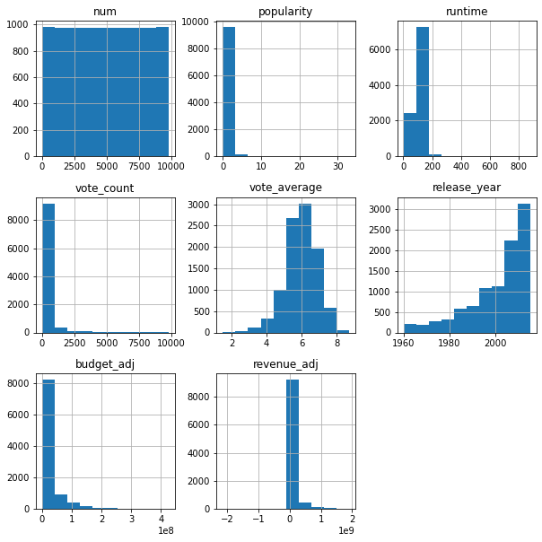

```python
#creating histogram to see the distribution of numerical values of our movie dataset
df.hist(figsize= (10,10));
```

As you can see popularity, runtime, vote_count and budget_adj more skewed to right while vote_average is more skewed to left.

Note that revenue_adj column has negative values. Release_year column is skewed to left.

### Research Question 3.1 (Is a movie more popular if it has a higher budget?)

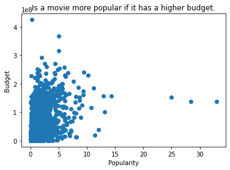

```python
#changed and used built in function
def plot_popularity_vs_budget(df):
    plt.scatter(df['popularity'], df['budget_adj'])
    plt.xlabel('Popularity')
    plt.ylabel('Budget')
    plt.title('Is a movie more popular if it has a higher budget.')
    plt.show()

plot_popularity_vs_budget(df)
```

The plot shows that there is some how correlation between popularity and budget. Movies with higher popularity scores do not necessarily have higher budgets or revenues. You can see even with higher budget, the movies popularity is less than or equal to 5.

### Research Question 3.2 (Is popularity depends on vote_average?)

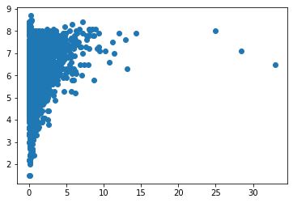

```python
#changed also this into lambda function which is not used in this notebook
(lambda df: plt.scatter(df['popularity'], df['vote_average']) or plt.xlabel('Popularity') or plt.ylabel('Vote_average') or plt.title('Is popularity depends on vote_average?') or plt.show())(df)
```

Firstly, answer for the title in the plot is partial Yes! Here we can not see high corelation. Without having lots of popularity score, vote_average for movies are high.

### Research Question 3.3 (Are movies getting shorter?)

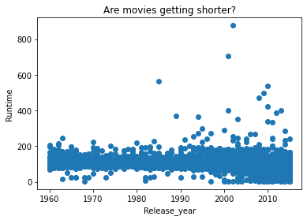

```python
#scatter plot of release_year vs runtime using Matplotlib:
plt.scatter(df['release_year'], df['runtime'])
plt.xlabel('Release_year')
plt.ylabel('Runtime')
plt.title('Are movies getting shorter?')
plt.show()
```

### Research Question 3.4 (To have more vote_counts lead to have high vote_average rating?)

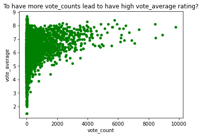

```python
#scatter plot of vote_count vs vote_average using plot.scatter() function:
vote_count_average = df.plot.scatter(x='vote_count', y='vote_average', c='green',
                                     title = "To have more vote_counts lead to have high vote_average rating?")
```

```python
#using numpy correlation between two columns which are vote_count and vote_average
vote_count = df['vote_count']
vote_average = df['vote_average']

correlation_matrix = np.corrcoef(vote_count, vote_average)
correlation_xy = correlation_matrix[0,1]
print(correlation_xy)
```

```
0.27985127914246916
```

The correlation coefficient ranges between -1 and 1. A value of -1 indicates a perfect negative correlation while a value of 1 indicates a perfect positive correlation. A value of 0 indicates no correlation between the two variables. In our case they are **positively correlated**.

### Research Question 3.5 (Is it true that movie with high vote_count tend to be popular?)

In order to get the answer for that question, let's make correlation matrix.

```python
#creating corr_matrix
corr_matrix = df.corr()

print(corr_matrix)
```

```
                   num  popularity   runtime  vote_count  vote_average  \
num           1.000000   -0.141787  0.088110   -0.119810      0.084732
popularity   -0.141787    1.000000  0.155790    0.802956      0.239121
runtime       0.088110    0.155790  1.000000    0.184234      0.191692
vote_count   -0.119810    0.802956  0.184234    1.000000      0.279851
vote_average  0.084732    0.239121  0.191692    0.279851      1.000000
release_year -0.733409    0.110944 -0.130601    0.124726     -0.140046
budget_adj   -0.017058    0.505378  0.248785    0.580444      0.109789
revenue_adj   0.031697    0.534260  0.179081    0.616374      0.197607

              release_year  budget_adj  revenue_adj
num              -0.733409   -0.017058     0.031697
popularity        0.110944    0.505378     0.534260
runtime          -0.130601    0.248785     0.179081
vote_count        0.124726    0.580444     0.616374
vote_average     -0.140046    0.109789     0.197607
release_year      1.000000    0.036102    -0.045753
budget_adj        0.036102    1.000000     0.602602
revenue_adj      -0.045753    0.602602     1.000000
```

```python
# print list of tuples to see highly correlated variables
high_corr_vars = corr_matrix.where(
    (corr_matrix > 0.7) & (corr_matrix < 1.0)
).stack().index.tolist()

print(high_corr_vars)
```

```
[('popularity', 'vote_count'), ('vote_count', 'popularity')]
```

As you can see from table above, the correlation between two variables are 0.802956. They are positively correlated. And answer for the question is **BIG YES**!

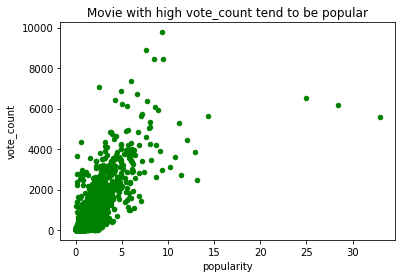

```python
#scatter plot of popularity vs vote_count using plot.scatter() function:
popularity_vote_count = df.plot.scatter(x='popularity', y='vote_count', c='green',
                                     title = "Movie with high vote_count tend to be popular")
```

### Research Question 4.1 (Which movie is the most profitable and which is the opposite?)

```python
# Create a new column named 'profit' which will contain the difference between revenue_adj and budget_adj columns
df['profit'] = df['revenue_adj'] - df['budget_adj']
df
```

|  | num | popularity | title | cast | director | runtime | genres | production_companies | vote_count | vote_average | release_year | budget_adj | revenue_adj | profit |
| --- | --- | --- | --- | --- | --- | --- | --- | --- | --- | --- | --- | --- | --- | --- |
| 0 | 0 | 32.985763 | Jurassic World | Chris Pratt\|Bryce Dallas Howard\|Irrfan Khan\|Vi... | Colin Trevorrow | 124 | Action\|Adventure\|Science Fiction\|Thriller | Universal Studios\|Amblin Entertainment\|Legenda... | 5562 | 6.5 | 2015 | 137999939 | 1392445892 | 1254445953 |
| 1 | 1 | 28.419936 | Mad Max: Fury Road | Tom Hardy\|Charlize Theron\|Hugh Keays-Byrne\|Nic... | George Miller | 120 | Action\|Adventure\|Science Fiction\|Thriller | Village Roadshow Pictures\|Kennedy Miller Produ... | 6185 | 7.1 | 2015 | 137999939 | 348161292 | 210161353 |
| 2 | 2 | 13.112507 | Insurgent | Shailene Woodley\|Theo James\|Kate Winslet\|Ansel... | Robert Schwentke | 119 | Adventure\|Science Fiction\|Thriller | Summit Entertainment\|Mandeville Films\|Red Wago... | 2480 | 6.3 | 2015 | 101199955 | 271619025 | 170419070 |
| 3 | 3 | 11.173104 | Star Wars: The Force Awakens | Harrison Ford\|Mark Hamill\|Carrie Fisher\|Adam D... | J.J. Abrams | 136 | Action\|Adventure\|Science Fiction\|Fantasy | Lucasfilm\|Truenorth Productions\|Bad Robot | 5292 | 7.5 | 2015 | 183999919 | 1902723129 | 1718723210 |
| 4 | 4 | 9.335014 | Furious 7 | Vin Diesel\|Paul Walker\|Jason Statham\|Michelle ... | James Wan | 137 | Action\|Crime\|Thriller | Universal Pictures\|Original Film\|Media Rights ... | 2947 | 7.3 | 2015 | 174799923 | 1385748801 | 1210948878 |
| ... | ... | ... | ... | ... | ... | ... | ... | ... | ... | ... | ... | ... | ... | ... |
| 9767 | 9767 | 0.080598 | The Endless Summer | Michael Hynson\|Robert August\|Lord 'Tally Ho' B... | Bruce Brown | 95 | Documentary | Bruce Brown Films | 11 | 7.4 | 1966 | 102 | 102 | 0 |
| 9768 | 9768 | 0.065543 | Grand Prix | James Garner\|Eva Marie Saint\|Yves Montand\|Tosh... | John Frankenheimer | 176 | Action\|Adventure\|Drama | Cherokee Productions\|Joel Productions\|Douglas ... | 20 | 5.7 | 1966 | 102 | 102 | 0 |
| 9769 | 9769 | 0.065141 | Beregis Avtomobilya | Innokentiy Smoktunovskiy\|Oleg Efremov\|Georgi Z... | Eldar Ryazanov | 94 | Mystery\|Comedy | Mosfilm | 11 | 6.5 | 1966 | 102 | 102 | 0 |
| 9770 | 9770 | 0.064317 | What's Up, Tiger Lily? | Tatsuya Mihashi\|Akiko Wakabayashi\|Mie Hama\|Joh... | Woody Allen | 80 | Action\|Comedy | Benedict Pictures Corp. | 22 | 5.4 | 1966 | 102 | 102 | 0 |
| 9771 | 9771 | 0.035919 | Manos: The Hands of Fate | Harold P. Warren\|Tom Neyman\|John Reynolds\|Dian... | Harold P. Warren | 74 | Horror | Norm-Iris | 15 | 1.5 | 1966 | 127642 | 102 | -127540 |

9772 rows × 14 columns

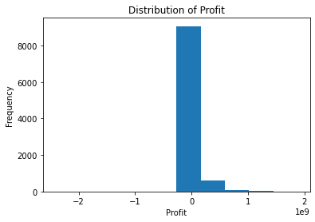

```python
#Create a histogram of the profit column
plt.hist(df['profit'])
plt.title('Distribution of Profit')
plt.xlabel('Profit')
plt.ylabel('Frequency')
plt.show()
```

```python
#printing the maximum and minimum profit for profit column
max_profit = df['profit'].max()
min_profit = df['profit'].min()

print(f'Maximum profit: {max_profit}')
print(f'Minimum profit: {min_profit}')
```

```
Maximum profit: 1878643093
Minimum profit: -2419175712
```

```python
#printing title of these two films
max_profit_film = df[df['profit'] == max_profit]['title'].values[0]
min_profit_film = df[df['profit'] == min_profit]['title'].values[0]

print(f'Film with maximum profit: {max_profit_film}')
print(f'Film with minimum profit: {min_profit_film}')
```

```
Film with maximum profit: Jaws
Film with minimum profit: Titanic
```

### Research Question 4.2 (How many movies are profitable in this dataset?)

```python
# Create new column named 'profitable' which will contain 'Yes' if the value in the profit column is positive and 'No' if it is negative
df['profitable'] = np.where(df['profit'] > 0, 'Yes', 'No')
df
```

|  | num | popularity | title | cast | director | runtime | genres | production_companies | vote_count | vote_average | release_year | budget_adj | revenue_adj | profit | profitable |
| --- | --- | --- | --- | --- | --- | --- | --- | --- | --- | --- | --- | --- | --- | --- | --- |
| 0 | 0 | 32.985763 | Jurassic World | Chris Pratt\|Bryce Dallas Howard\|Irrfan Khan\|Vi... | Colin Trevorrow | 124 | Action\|Adventure\|Science Fiction\|Thriller | Universal Studios\|Amblin Entertainment\|Legenda... | 5562 | 6.5 | 2015 | 137999939 | 1392445892 | 1254445953 | Yes |
| 1 | 1 | 28.419936 | Mad Max: Fury Road | Tom Hardy\|Charlize Theron\|Hugh Keays-Byrne\|Nic... | George Miller | 120 | Action\|Adventure\|Science Fiction\|Thriller | Village Roadshow Pictures\|Kennedy Miller Produ... | 6185 | 7.1 | 2015 | 137999939 | 348161292 | 210161353 | Yes |
| 2 | 2 | 13.112507 | Insurgent | Shailene Woodley\|Theo James\|Kate Winslet\|Ansel... | Robert Schwentke | 119 | Adventure\|Science Fiction\|Thriller | Summit Entertainment\|Mandeville Films\|Red Wago... | 2480 | 6.3 | 2015 | 101199955 | 271619025 | 170419070 | Yes |
| 3 | 3 | 11.173104 | Star Wars: The Force Awakens | Harrison Ford\|Mark Hamill\|Carrie Fisher\|Adam D... | J.J. Abrams | 136 | Action\|Adventure\|Science Fiction\|Fantasy | Lucasfilm\|Truenorth Productions\|Bad Robot | 5292 | 7.5 | 2015 | 183999919 | 1902723129 | 1718723210 | Yes |
| 4 | 4 | 9.335014 | Furious 7 | Vin Diesel\|Paul Walker\|Jason Statham\|Michelle ... | James Wan | 137 | Action\|Crime\|Thriller | Universal Pictures\|Original Film\|Media Rights ... | 2947 | 7.3 | 2015 | 174799923 | 1385748801 | 1210948878 | Yes |
| ... | ... | ... | ... | ... | ... | ... | ... | ... | ... | ... | ... | ... | ... | ... | ... |
| 9767 | 9767 | 0.080598 | The Endless Summer | Michael Hynson\|Robert August\|Lord 'Tally Ho' B... | Bruce Brown | 95 | Documentary | Bruce Brown Films | 11 | 7.4 | 1966 | 102 | 102 | 0 | No |
| 9768 | 9768 | 0.065543 | Grand Prix | James Garner\|Eva Marie Saint\|Yves Montand\|Tosh... | John Frankenheimer | 176 | Action\|Adventure\|Drama | Cherokee Productions\|Joel Productions\|Douglas ... | 20 | 5.7 | 1966 | 102 | 102 | 0 | No |
| 9769 | 9769 | 0.065141 | Beregis Avtomobilya | Innokentiy Smoktunovskiy\|Oleg Efremov\|Georgi Z... | Eldar Ryazanov | 94 | Mystery\|Comedy | Mosfilm | 11 | 6.5 | 1966 | 102 | 102 | 0 | No |
| 9770 | 9770 | 0.064317 | What's Up, Tiger Lily? | Tatsuya Mihashi\|Akiko Wakabayashi\|Mie Hama\|Joh... | Woody Allen | 80 | Action\|Comedy | Benedict Pictures Corp. | 22 | 5.4 | 1966 | 102 | 102 | 0 | No |
| 9771 | 9771 | 0.035919 | Manos: The Hands of Fate | Harold P. Warren\|Tom Neyman\|John Reynolds\|Dian... | Harold P. Warren | 74 | Horror | Norm-Iris | 15 | 1.5 | 1966 | 127642 | 102 | -127540 | No |

9772 rows × 15 columns

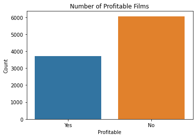

```python
#create a count plot with ‘profitable’ column on the x-axis and the number of profitable films on the y-axis.
sns.countplot(x='profitable', data=df)
plt.title('Number of Profitable Films')
plt.xlabel('Profitable')
plt.ylabel('Count')
plt.show()
```

```python
#printing number of profitable and non-profitable films
num_profitable = len(df[df['profitable'] == 'Yes'])
num_non_profitable = len(df[df['profitable'] == 'No'])

print(f'Number of profitable films: {num_profitable}')
print(f'Number of non-profitable films: {num_non_profitable}')
```

```
Number of profitable films: 3708
Number of non-profitable films: 6064
```

You can see that there are non profitable films which are more than profitable films

# Conclusions

> **Tip**: Finally, summarize your findings and the results that have been performed. Make sure that you are clear with regards to the limitations of your exploration. If you haven't done any statistical tests, do not imply any statistical conclusions. And make sure you avoid implying causation from correlation!

> **Tip**: Once you are satisfied with your work, you should save a copy of the report in HTML or PDF form via the **File** > **Download as** submenu. Before exporting your report, check over it to make sure that the flow of the report is complete. You should probably remove all of the "Tip" quotes like this one so that the presentation is as tidy as possible. Congratulations! Here are the section for conclusion content: you can go through the links below:
- Summary
- Limitations
- Used functions
- Further analysis
- Resources

## Summary

In conclusion I want to summarize my findings according to my answers for the questions:

1. We have top 5 films which has the highest vote count, highest budget, highest revenue, highest popularity score, highest vote_average for each category.

2. From the histogram, we can see popularity, runtime, vote_count and budget_adj more skewed to right while vote_average is more skewed to left. Release_year column is skewed to left. From this website(stats.libretexts.org) If the distribution of data is skewed to the left, the mean is less than the median, which is often less than the mode. If the distribution of data is skewed to the right, the mode is often less than the median, which is less than the mean.

3.1. I can say that there is small positive correlation between two variables popularity and budget_adj. Anyways, movies with higher popularity scores do not necessarily have higher budgets or revenues.

3.2. Popularity depends on vote_average partially. Because, there are some other cases, when having lots of popularity score, vote_average for movies are high.

3.5. It is true that movie with high vote_count tend to be popular.

## Limitations

### *Limitation 1.*

I dropped movies which has null values in its columns that's why movies with good rating, or high budget_adj **MAYBE** omitted from this dataset. So we may not always get accurate results. It will be tentative.

### *Limitation 2.*

I dropped budget and revenue and keeping the other two columns budget_adj and revenue_adj. I want to use budget_adj and revenue_adj columns as they account for inflation to compare budgets and revenues accross different years. It is my choice. That's why profit and other values will be really different.

### *Limitation 4.*

I am taking values in the column named `budget_adj` and `revenue_adj` as a currency **dollar**.

## Functions

I used lambda functions to replace spaces with underscores and lowercase labels for movie dataset. Moreover, lambda function is used to change the format of the values in the column in this dataset for changing scientific notations.

I used many built-in functions in Python like `pop()` and `str.capitalize()`. `pop()` is a method used to remove and return the last element from a list. `str.capitalize()` is a method used to capitalize the first character of a string. I used `astype()` which is a built-in method in Python's NumPy library that converts an array to a specified data type. It can be used to convert the data type of any NumPy array element-wise. There is more than that, you can see while you check.

Furthermore, I creatied dataframes, created tuples, and dictionaries and for loops in order to use for appropriate cases.

You can also see the usage of `pandas`, `numpy`, `matplotlib` and `seaborn` Python packages.

## Further analysis

I didn't have so much time to further analysis. If you want to continue you can answer these questions:

- Which actors played in many films?
- Are there any directors who directed more than 5 films or more?
- Which genre are popular among this dataset?
- In which decade, we have earned biggest amount of dollars for movies?

## Resources

- https://www.kaggle.com/datasets/muqarrishzaib/tmdb-10000-movies-dataset - Meaning of datasets
- https://www.kaggle.com/datasets/tmdb/tmdb-movie-metadata?select=tmdb_5000_movies.csv - About dataset
- https://github.com/Mehrol911/Airbnb-Listings-in-the-state-of-New-York/edit/main/README.md - My notebook for inspiration to write introduction section
- https://www.geeksforgeeks.org/find-duplicate-rows-in-a-dataframe-based-on-all-or-selected-columns/ - To find duplicate rows
- https://stackoverflow.com/questions/12168648/pandas-python-how-to-add-column-to-dataframe-for-index - Adding column to a dataframe
- https://www.geeksforgeeks.org/how-to-move-a-column-to-first-position-in-pandas-dataframe/ - Moving a column to the first position
- http://pandas.pydata.org - Data Wrangling with pandas Cheat Sheet
- https://www.cambridgemaths.org/blogs/skewed-usage-skewed-distribution/ - Skewness usage
- https://www.scribbr.com/statistics/skewness/ - Skewness
- https://datagy.io/python-correlation-matrix/ - Calculating corr matrix
- https://www.askpython.com/python/examples/correlation-regression-analysis - Corrrelation coefficient ranges
- Udacity GPT
- Bing search Engine

### Started: 07.04.2023

### Finished: 11.04.2023

```python
print('If I had had time, I would have put some pictures to my notebook in order to make it outstanding')
```

```
If I had had time, I would have put some pictures to my notebook in order to make it outstanding
```